# Contagious Yawning in Dogs: Re-analysis (Part 1)

Scott Claessens and Patrick Neilands

2019-12-19

The purpose of this document is to re-analyse the data from six studies of contagious yawning in dogs. These studies are:

- [Joly-Mascheroni et al. (2008)](https://royalsocietypublishing.org/doi/abs/10.1098/rsbl.2008.0333)
- [O’Hara & Reeve (2011)](https://www.sciencedirect.com/science/article/pii/S0003347210004483)
- [Silva et al. (2012)](https://link.springer.com/article/10.1007/s10071-012-0473-2)
- [Madsen & Persson (2013)](https://link.springer.com/article/10.1007/s10071-012-0568-9)
- [Romero et al. (2013)](https://journals.plos.org/plosone/article?id=10.1371/journal.pone.0071365)
- [Buttner & Strasser (2014)](https://link.springer.com/article/10.1007/s10071-013-0641-z)

We would like to thank the authors of these studies for kindly sharing their original data with us.

# 0. Setup

Load the data.

```r
d <-
  read.csv('data/yawnReanalysis.csv') %>%
  as_tibble() %>%
  # create dummy variables for re-analysis
  mutate(condition    = ifelse(condition == "Control", 0, 1),
         familiar     = ifelse(familiar  == "Unfamiliar", 0, 1),
         type         = ifelse(type == "Shelter", 0, 1),
         presentation = ifelse(presentation == "A", 0, 1),
         live         = ifelse(live == "Recording", 0, 1),
         demonstrator = ifelse(demonstrator == "Human", 0, 1),
         male         = ifelse(gender == 'F', 0, 1))

d
```

| ID | study | numberYawns | age | gender | trial | condition | presentation | type | demonstrator | familiar | live | secs | male |
| --- | --- | --- | --- | --- | --- | --- | --- | --- | --- | --- | --- | --- | --- |
| P1 | JM et al | 1 | 5.0000000 | M | 2 | 1 | 1 | 1 | 0 | 0 | 1 | 300 | 1 |
| P2 | JM et al | 5 | 8.0000000 | M | 2 | 1 | 1 | 1 | 0 | 0 | 1 | 300 | 1 |
| P3 | JM et al | 1 | 7.0000000 | M | 1 | 1 | 1 | 1 | 0 | 0 | 1 | 300 | 1 |
| P4 | JM et al | 1 | 4.0000000 | F | 2 | 1 | 1 | 1 | 0 | 0 | 1 | 300 | 0 |
| P5 | JM et al | 2 | 5.0000000 | F | 1 | 1 | 1 | 1 | 0 | 0 | 1 | 300 | 0 |
| P6 | JM et al | 0 | 15.0000000 | M | 2 | 1 | 1 | 1 | 0 | 0 | 1 | 300 | 1 |
| P7 | JM et al | 0 | 7.0000000 | F | 2 | 1 | 1 | 1 | 0 | 0 | 1 | 300 | 0 |
| P8 | JM et al | 1 | 15.0000000 | M | 2 | 1 | 1 | 1 | 0 | 0 | 1 | 300 | 1 |
| P9 | JM et al | 2 | 8.0000000 | M | 1 | 1 | 1 | 1 | 0 | 0 | 1 | 300 | 1 |
| P10 | JM et al | 1 | 5.0000000 | M | 2 | 1 | 1 | 1 | 0 | 0 | 1 | 300 | 1 |

[output cut: 676 more lines]

Visualise the outcome.

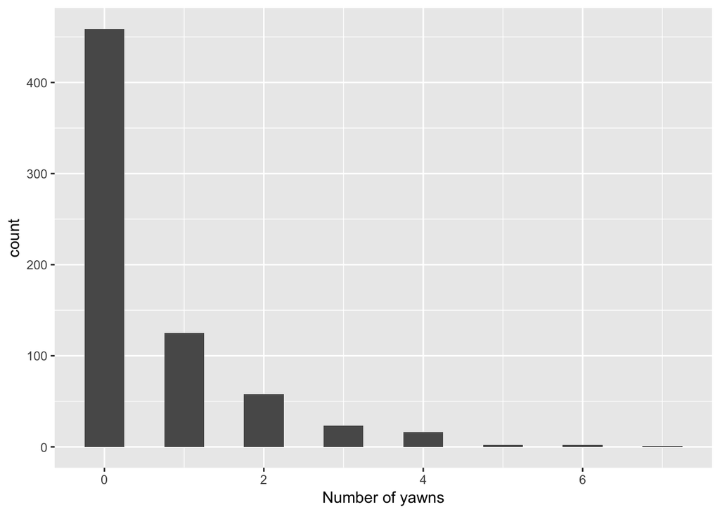

And split by study.

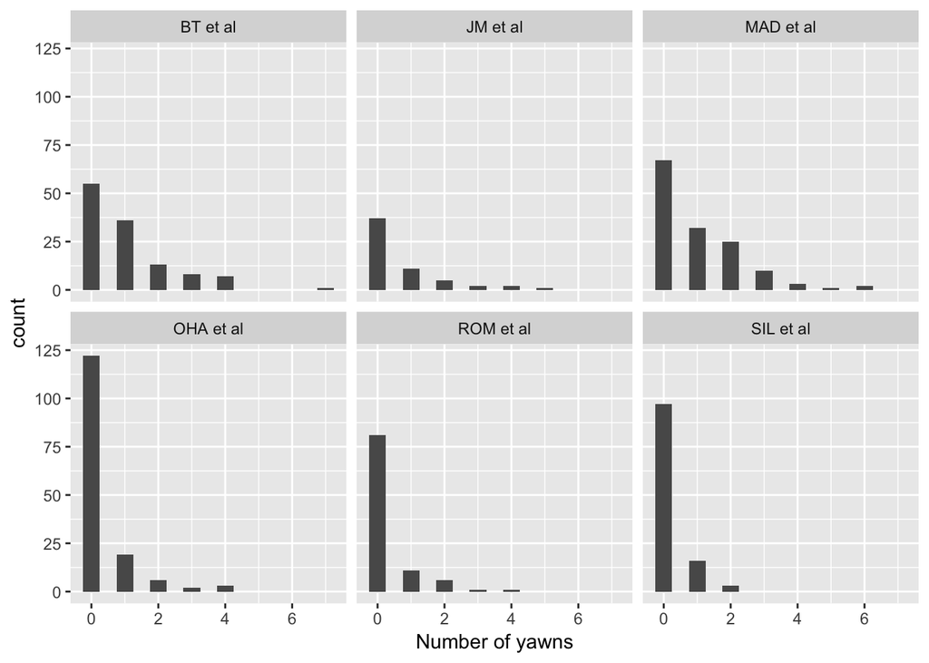

These look zero-inflated. A zero-inflated Poisson model follows the general form

$$\begin{eqnarray}
y_i & \sim & \text{ZIPoisson} (p_i, \lambda_i)\\
\text{logit} (p_i) & = & \alpha_p + \beta_p x_i \\
\text{log} (\lambda_i) & = & \alpha_\lambda + \text{log(offset)} + \beta_\lambda x_i
\end{eqnarray}$$

where $p_i$ is the zero-inflation probability (so $1 - p_i$ is the probability of the process getting started). $\text{log(offset)}$ is the log of the exposure length, and simple algebra means that $\lambda_i$ is now the expected *rate* per exposure length, rather than the count.

To ensure that this class of model is the best fit to the data, we also run other classes of models (such as Poisson, hurdle Poisson, negative binomial, hurdle negative binomial, and zero-inflated negative binomial models) and compare using information criteria.

# 1. Fit zero-inflated Poisson models

## 1.1. Intercept-only model

We utlise a Bayesian multilevel modelling approach here, including random effects for individual dogs nested within studies. Throughout, we use the same linear model to predict $\lambda_i$ (the rate of yawning) and $p_i$ (the probability of the yawning process never even getting started). The latter is called `zi` inside the model formula.

To begin, we fit an intercept-only model.

```
##  Family: zero_inflated_poisson
##   Links: mu = log; zi = logit
## Formula: numberYawns ~ 0 + intercept + offset(log(secs)) + (0 + intercept | study/ID)
##          zi ~ 0 + intercept + (0 + intercept | study/ID)
##    Data: d (Number of observations: 686)
## Samples: 4 chains, each with iter = 2000; warmup = 1000; thin = 1;
##          total post-warmup samples = 4000
##
## Group-Level Effects:
## ~study (Number of levels: 6)
##                  Estimate Est.Error l-95% CI u-95% CI Rhat Bulk_ESS Tail_ESS
## sd(intercept)        0.50      0.32     0.11     1.31 1.00     1226     1632
## sd(zi_intercept)     0.82      0.42     0.14     1.86 1.00      863      498
##
## ~study:ID (Number of levels: 197)
##                  Estimate Est.Error l-95% CI u-95% CI Rhat Bulk_ESS Tail_ESS
## sd(intercept)        0.55      0.12     0.31     0.78 1.00      871     1195
## sd(zi_intercept)     0.47      0.36     0.02     1.34 1.01      547     1276
##
## Population-Level Effects:
##              Estimate Est.Error l-95% CI u-95% CI Rhat Bulk_ESS Tail_ESS
## intercept       -5.92      0.28    -6.41    -5.32 1.00     1223     1628
## zi_intercept    -0.62      0.45    -1.55     0.25 1.00     1981     2499
##
## Samples were drawn using sampling(NUTS). For each parameter, Eff.Sample
## is a crude measure of effective sample size, and Rhat is the potential
## scale reduction factor on split chains (at convergence, Rhat = 1).
```

What priors did we use?

| prior | class | coef | group | resp | dpar | nlpar | bound |
| --- | --- | --- | --- | --- | --- | --- | --- |
|  | b |  |  |  |  |  |  |
| student_t(3, -2, 10) | b | intercept |  |  |  |  |  |
|  | b |  |  |  | zi |  |  |
| logistic(0, 1) | b | intercept |  |  | zi |  |  |
| student_t(3, 0, 10) | sd |  |  |  |  |  |  |
| student_t(3, 0, 0.5) | sd |  |  |  | zi |  |  |
|  | sd |  | study |  |  |  |  |
|  | sd | intercept | study |  |  |  |  |
|  | sd |  | study |  | zi |  |  |
|  | sd | intercept | study |  | zi |  |  |

[output cut: 4 more lines]

Let’s interpret each parameter in turn. The zero-inflation parameter `zi` is -0.62. This is on the logit scale, so we need to calculate the inverse logit.

```r
post <- posterior_samples(m1.1)

1 - inv_logit_scaled(post$b_zi_intercept) %>% # prob of yawning process getting started
  median() %>%
  round(2)
```

```
## [1] 0.64
```

The median probability of the yawning process getting started is 0.64.

Let’s calculate the average yawning rate once the yawning process gets started.

```r
(exp(post$b_intercept) * 60) %>% # Yawning rate (per min)
  median() %>%
  round(2)
```

```
## [1] 0.16
```

The dogs yawn 0.16 times a minute, on average.

## 1.2. Condition-only model

Next, we add condition to the model, also as a random effect grouped by individual dogs nested within studies.

```
##  Family: zero_inflated_poisson
##   Links: mu = log; zi = logit
## Formula: numberYawns ~ 0 + intercept + condition + offset(log(secs)) + (0 + intercept + condition | study/ID)
##          zi ~ 0 + intercept + condition + (0 + intercept + condition | study/ID)
##    Data: d (Number of observations: 686)
## Samples: 4 chains, each with iter = 2000; warmup = 1000; thin = 1;
##          total post-warmup samples = 4000
##
## Group-Level Effects:
## ~study (Number of levels: 6)
##                                Estimate Est.Error l-95% CI u-95% CI Rhat Bulk_ESS Tail_ESS
## sd(intercept)                      1.26      0.79     0.31     3.35 1.01      781      732
## sd(condition)                      1.52      0.84     0.55     3.60 1.01      950     1312
## sd(zi_intercept)                   0.60      0.51     0.02     1.87 1.00     1216     2160
## sd(zi_condition)                   0.91      0.66     0.05     2.50 1.00     1276     1714
## cor(intercept,condition)          -0.72      0.32    -0.99     0.19 1.00     1004      944
## cor(zi_intercept,zi_condition)     0.14      0.55    -0.90     0.96 1.00     1577     2194
##
## ~study:ID (Number of levels: 197)
##                                Estimate Est.Error l-95% CI u-95% CI Rhat Bulk_ESS Tail_ESS
## sd(intercept)                      0.60      0.16     0.28     0.94 1.00      619      717
## sd(condition)                      0.23      0.16     0.01     0.61 1.00      816     1723
## sd(zi_intercept)                   0.68      0.57     0.03     2.14 1.00      441     1107
## sd(zi_condition)                   0.36      0.30     0.01     1.11 1.00     2135     1668
## cor(intercept,condition)          -0.37      0.52    -0.98     0.85 1.00     1984     2329
## cor(zi_intercept,zi_condition)    -0.02      0.58    -0.95     0.95 1.00     2955     2355
##
## Population-Level Effects:
##              Estimate Est.Error l-95% CI u-95% CI Rhat Bulk_ESS Tail_ESS
## intercept       -6.81      0.56    -7.87    -5.55 1.00     1015     1026
## condition        0.93      0.57    -0.39     1.95 1.00     1311     1497
## zi_intercept    -1.29      0.72    -2.89    -0.05 1.00     1284     2122
## zi_condition    -0.17      0.68    -1.53     1.18 1.00     2355     2444
##
## Samples were drawn using sampling(NUTS). For each parameter, Eff.Sample
## is a crude measure of effective sample size, and Rhat is the potential
## scale reduction factor on split chains (at convergence, Rhat = 1).
```

What priors did we use?

| prior | class | coef | group | resp | dpar | nlpar | bound |
| --- | --- | --- | --- | --- | --- | --- | --- |
|  | b |  |  |  |  |  |  |
| normal(0, 1) | b | condition |  |  |  |  |  |
| student_t(3, -2, 10) | b | intercept |  |  |  |  |  |
|  | b |  |  |  | zi |  |  |
| normal(0, 1) | b | condition |  |  | zi |  |  |
| logistic(0, 1) | b | intercept |  |  | zi |  |  |
| lkj_corr_cholesky(1) | L |  |  |  |  |  |  |
|  | L |  | study |  |  |  |  |
|  | L |  | study:ID |  |  |  |  |
| student_t(3, 0, 10) | sd |  |  |  |  |  |  |

[output cut: 13 more lines]

Get difference between conditions.

```r
post <- posterior_samples(m1.2)

# yawning rates (per minute)
cond1 <- exp(post$b_intercept) * 60
median(cond1) %>% round(2)
```

```
## [1] 0.07
```

```r
cond2 <- exp(post$b_intercept + post$b_condition) * 60
median(cond2) %>% round(2)
```

```
## [1] 0.17
```

```r
diff <- cond2 - cond1

# proportion of prob mass above zero
(sum(diff > 0) / length(diff)) %>% round(2)
```

```
## [1] 0.95
```

Visualise effect of condition (we call it “Treatment” in our figures due to a comment from a reviewer).

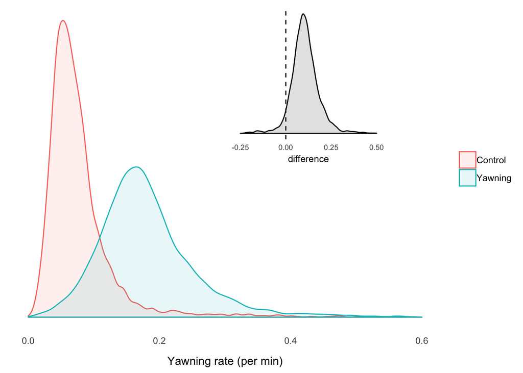

The effect of condition across studies.

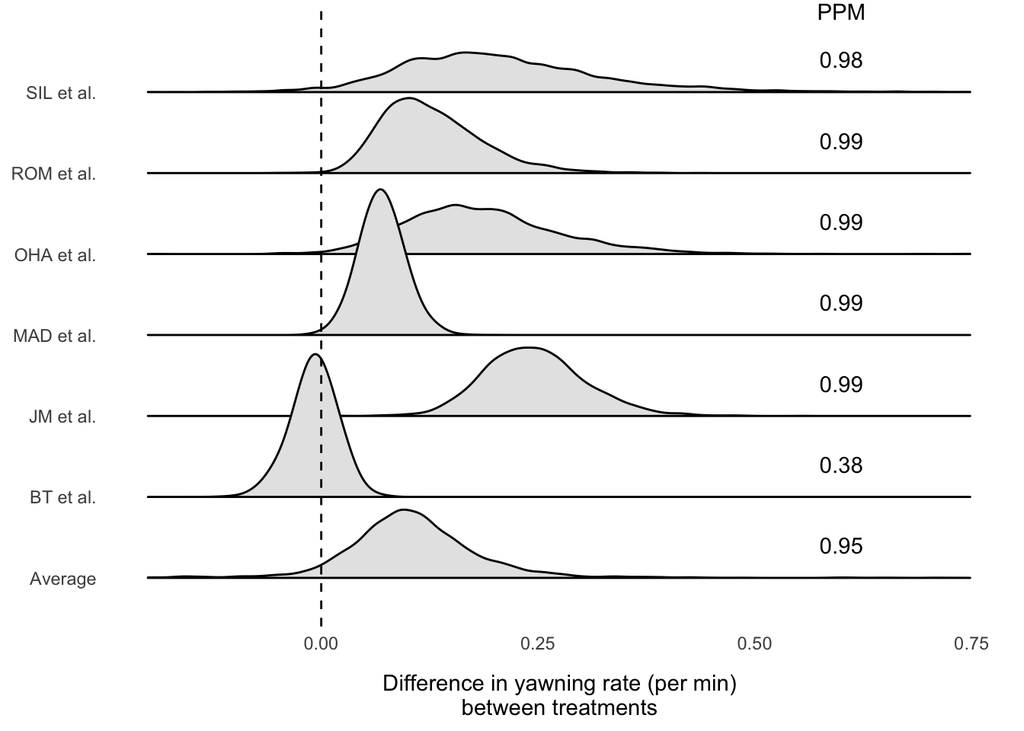

## 1.3. Familiarity-only model

```
##  Family: zero_inflated_poisson
##   Links: mu = log; zi = logit
## Formula: numberYawns ~ 0 + intercept + familiar + offset(log(secs)) + (0 + intercept | study/ID)
##          zi ~ 0 + intercept + familiar + (0 + intercept | study/ID)
##    Data: d (Number of observations: 686)
## Samples: 4 chains, each with iter = 2000; warmup = 1000; thin = 1;
##          total post-warmup samples = 4000
##
## Group-Level Effects:
## ~study (Number of levels: 6)
##                  Estimate Est.Error l-95% CI u-95% CI Rhat Bulk_ESS Tail_ESS
## sd(intercept)        0.50      0.32     0.10     1.34 1.00      824      939
## sd(zi_intercept)     0.90      0.43     0.24     1.91 1.00     1306     1011
##
## ~study:ID (Number of levels: 197)
##                  Estimate Est.Error l-95% CI u-95% CI Rhat Bulk_ESS Tail_ESS
## sd(intercept)        0.52      0.13     0.26     0.76 1.00      631      560
## sd(zi_intercept)     0.47      0.38     0.02     1.41 1.00      491      925
##
## Population-Level Effects:
##              Estimate Est.Error l-95% CI u-95% CI Rhat Bulk_ESS Tail_ESS
## intercept       -6.04      0.28    -6.57    -5.50 1.00     1470     1955
## familiar         0.37      0.18     0.01     0.72 1.00     2959     2910
## zi_intercept    -0.83      0.50    -1.82     0.12 1.00     1766     2083
## zi_familiar      0.75      0.41    -0.05     1.56 1.00     2858     3003
##
## Samples were drawn using sampling(NUTS). For each parameter, Eff.Sample
## is a crude measure of effective sample size, and Rhat is the potential
## scale reduction factor on split chains (at convergence, Rhat = 1).
```

What priors did we use?

| prior | class | coef | group | resp | dpar | nlpar | bound |
| --- | --- | --- | --- | --- | --- | --- | --- |
|  | b |  |  |  |  |  |  |
| normal(0, 1) | b | familiar |  |  |  |  |  |
| student_t(3, -2, 10) | b | intercept |  |  |  |  |  |
|  | b |  |  |  | zi |  |  |
| normal(0, 1) | b | familiar |  |  | zi |  |  |
| logistic(0, 1) | b | intercept |  |  | zi |  |  |
| student_t(3, 0, 10) | sd |  |  |  |  |  |  |
| student_t(3, 0, 0.5) | sd |  |  |  | zi |  |  |
|  | sd |  | study |  |  |  |  |
|  | sd | intercept | study |  |  |  |  |

[output cut: 6 more lines]

## 1.4. Condition + Familiarity model

We include both condition and familiarity as additive effects.

```
##  Family: zero_inflated_poisson
##   Links: mu = log; zi = logit
## Formula: numberYawns ~ 0 + intercept + condition + familiar + offset(log(secs)) + (0 + intercept + condition | study/ID)
##          zi ~ 0 + intercept + condition + familiar + (0 + intercept + condition | study/ID)
##    Data: d (Number of observations: 686)
## Samples: 4 chains, each with iter = 2000; warmup = 1000; thin = 1;
##          total post-warmup samples = 4000
##
## Group-Level Effects:
## ~study (Number of levels: 6)
##                                Estimate Est.Error l-95% CI u-95% CI Rhat Bulk_ESS Tail_ESS
## sd(intercept)                      1.21      0.79     0.29     3.14 1.00     1172     1162
## sd(condition)                      1.52      0.84     0.55     3.56 1.00     1310     1877
## sd(zi_intercept)                   0.66      0.56     0.03     1.99 1.00     1978     2785
## sd(zi_condition)                   0.85      0.65     0.05     2.48 1.00     1664     2353
## cor(intercept,condition)          -0.73      0.30    -0.99     0.14 1.00     1734     2195
## cor(zi_intercept,zi_condition)     0.15      0.56    -0.91     0.97 1.00     2729     2524
##
## ~study:ID (Number of levels: 197)
##                                Estimate Est.Error l-95% CI u-95% CI Rhat Bulk_ESS Tail_ESS
## sd(intercept)                      0.58      0.17     0.25     0.91 1.01      739     1145
## sd(condition)                      0.23      0.16     0.01     0.61 1.00     1106     1846
## sd(zi_intercept)                   0.67      0.57     0.02     2.08 1.01      639     1113
## sd(zi_condition)                   0.39      0.33     0.01     1.24 1.00     2180     2424
## cor(intercept,condition)          -0.34      0.52    -0.97     0.86 1.00     3042     2895
## cor(zi_intercept,zi_condition)     0.00      0.58    -0.94     0.94 1.00     4205     3286
##
## Population-Level Effects:
##              Estimate Est.Error l-95% CI u-95% CI Rhat Bulk_ESS Tail_ESS
## intercept       -6.86      0.53    -7.86    -5.68 1.00     1982     2236
## condition        0.86      0.56    -0.41     1.89 1.00     2414     2327
## familiar         0.31      0.19    -0.07     0.68 1.00     4365     3138
## zi_intercept    -1.38      0.70    -2.95    -0.15 1.00     2069     2630
## zi_condition    -0.35      0.66    -1.63     0.97 1.00     3698     2983
## zi_familiar      0.73      0.56    -0.44     1.85 1.00     3969     3328
##
## Samples were drawn using sampling(NUTS). For each parameter, Eff.Sample
## is a crude measure of effective sample size, and Rhat is the potential
## scale reduction factor on split chains (at convergence, Rhat = 1).
```

What priors did we use?

| prior | class | coef | group | resp | dpar | nlpar | bound |
| --- | --- | --- | --- | --- | --- | --- | --- |
|  | b |  |  |  |  |  |  |
| normal(0, 1) | b | condition |  |  |  |  |  |
| normal(0, 1) | b | familiar |  |  |  |  |  |
| student_t(3, -2, 10) | b | intercept |  |  |  |  |  |
|  | b |  |  |  | zi |  |  |
| normal(0, 1) | b | condition |  |  | zi |  |  |
| normal(0, 1) | b | familiar |  |  | zi |  |  |
| logistic(0, 1) | b | intercept |  |  | zi |  |  |
| lkj_corr_cholesky(1) | L |  |  |  |  |  |  |
|  | L |  | study |  |  |  |  |

[output cut: 15 more lines]

Get difference between conditions, controlling for familiarity.

```r
post <- posterior_samples(m1.4)

# yawning rates (per minute)
cond1 <- exp(post$b_intercept) * 60
median(cond1) %>% round(2)
```

```
## [1] 0.06
```

```r
cond2 <- exp(post$b_intercept + post$b_condition) * 60
median(cond2) %>% round(2)
```

```
## [1] 0.15
```

```r
diff <- cond2 - cond1

# proportion of prob mass above zero
(sum(diff > 0) / length(diff)) %>% round(2)
```

```
## [1] 0.93
```

## 1.5. Condition*Familiarity model

Finally, we allow condition and familiarity to interact with one another.

```
##  Family: zero_inflated_poisson
##   Links: mu = log; zi = logit
## Formula: numberYawns ~ 0 + intercept + condition * familiar + offset(log(secs)) + (0 + intercept + condition | study/ID)
##          zi ~ 0 + intercept + condition * familiar + (0 + intercept + condition | study/ID)
##    Data: d (Number of observations: 686)
## Samples: 4 chains, each with iter = 3000; warmup = 1500; thin = 1;
##          total post-warmup samples = 6000
##
## Group-Level Effects:
## ~study (Number of levels: 6)
##                                Estimate Est.Error l-95% CI u-95% CI Rhat Bulk_ESS Tail_ESS
## sd(intercept)                      1.22      0.76     0.28     3.16 1.00     1299     1616
## sd(condition)                      1.52      0.84     0.54     3.70 1.00     1662     2873
## sd(zi_intercept)                   0.66      0.57     0.02     2.14 1.00     1592     2238
## sd(zi_condition)                   0.87      0.69     0.04     2.56 1.00     2073     2880
## cor(intercept,condition)          -0.72      0.31    -0.99     0.17 1.00     2163     3111
## cor(zi_intercept,zi_condition)     0.15      0.55    -0.91     0.96 1.00     2889     3288
##
## ~study:ID (Number of levels: 197)
##                                Estimate Est.Error l-95% CI u-95% CI Rhat Bulk_ESS Tail_ESS
## sd(intercept)                      0.59      0.16     0.25     0.92 1.00      893     1000
## sd(condition)                      0.22      0.16     0.01     0.61 1.00     1170     2736
## sd(zi_intercept)                   0.65      0.58     0.02     2.14 1.00      664     1397
## sd(zi_condition)                   0.39      0.34     0.01     1.27 1.00     2548     2819
## cor(intercept,condition)          -0.34      0.53    -0.98     0.86 1.00     3108     3315
## cor(zi_intercept,zi_condition)    -0.01      0.57    -0.96     0.95 1.00     4142     3484
##
## Population-Level Effects:
##                       Estimate Est.Error l-95% CI u-95% CI Rhat Bulk_ESS Tail_ESS
## intercept                -6.88      0.55    -7.97    -5.71 1.00     1837     2223
## condition                 0.86      0.58    -0.39     1.96 1.00     2301     2321
## familiar                  0.26      0.31    -0.32     0.87 1.00     3368     4199
## condition:familiar        0.06      0.34    -0.61     0.71 1.00     3816     3971
## zi_intercept             -1.45      0.71    -3.01    -0.22 1.00     2665     3760
## zi_condition             -0.28      0.67    -1.60     1.04 1.00     3483     4271
## zi_familiar               0.78      0.69    -0.72     2.04 1.00     3871     4000
## zi_condition:familiar    -0.16      0.73    -1.59     1.33 1.00     4120     4245
##
## Samples were drawn using sampling(NUTS). For each parameter, Eff.Sample
## is a crude measure of effective sample size, and Rhat is the potential
## scale reduction factor on split chains (at convergence, Rhat = 1).
```

What priors did we use?

| prior | class | coef | group | resp | dpar | nlpar | bound |
| --- | --- | --- | --- | --- | --- | --- | --- |
|  | b |  |  |  |  |  |  |
| normal(0, 1) | b | condition |  |  |  |  |  |
| normal(0, 1) | b | condition:familiar |  |  |  |  |  |
| normal(0, 1) | b | familiar |  |  |  |  |  |
| student_t(3, -2, 10) | b | intercept |  |  |  |  |  |
|  | b |  |  |  | zi |  |  |
| normal(0, 1) | b | condition |  |  | zi |  |  |
| normal(0, 1) | b | condition:familiar |  |  | zi |  |  |
| normal(0, 1) | b | familiar |  |  | zi |  |  |
| logistic(0, 1) | b | intercept |  |  | zi |  |  |

[output cut: 17 more lines]

Get yawning rate in each cell of 2x2 design.

```r
post <- posterior_samples(m1.5)

# yawning rates (per minute)
cond1unfam <- exp(post$b_intercept) * 60
cond2unfam <- exp(post$b_intercept + post$b_condition) * 60
cond1fam   <- exp(post$b_intercept + post$b_familiar) * 60
cond2fam   <- exp(post$b_intercept + post$b_condition +
                    post$b_familiar + post$`b_condition:familiar`) * 60

median(cond1unfam) %>% round(2)
```

```
## [1] 0.06
```

```r
median(cond2unfam) %>% round(2)
```

```
## [1] 0.15
```

```r
median(cond1fam) %>% round(2)
```

```
## [1] 0.08
```

```r
median(cond2fam) %>% round(2)
```

```
## [1] 0.21
```

Are there any differences in yawning rate? Get proportions of prob mass above zero for each contrast.

```r
diff1 <- cond2fam - cond1unfam
diff2 <- cond2fam - cond2unfam
diff3 <- cond2fam - cond1fam
diff4 <- cond1fam - cond1unfam
diff5 <- cond1fam - cond2unfam
diff6 <- cond2unfam - cond1unfam

(sum(diff1 > 0) / length(diff1)) %>% round(2)
```

```
## [1] 0.97
```

```r
(sum(diff2 > 0) / length(diff2)) %>% round(2)
```

```
## [1] 0.94
```

```r
(sum(diff3 > 0) / length(diff3)) %>% round(2)
```

```
## [1] 0.92
```

```r
(sum(diff4 > 0) / length(diff4)) %>% round(2)
```

```
## [1] 0.8
```

```r
(sum(diff5 > 0) / length(diff5)) %>% round(2)
```

```
## [1] 0.16
```

```r
(sum(diff6 > 0) / length(diff6)) %>% round(2)
```

```
## [1] 0.93
```

Does the effect of condition differ between familiar and unfamiliar demonstrators? Interaction effect.

```r
(sum(diff3 - diff6 > 0) / length(diff3)) %>% round(2)
```

```
## [1] 0.78
```

Visualise.

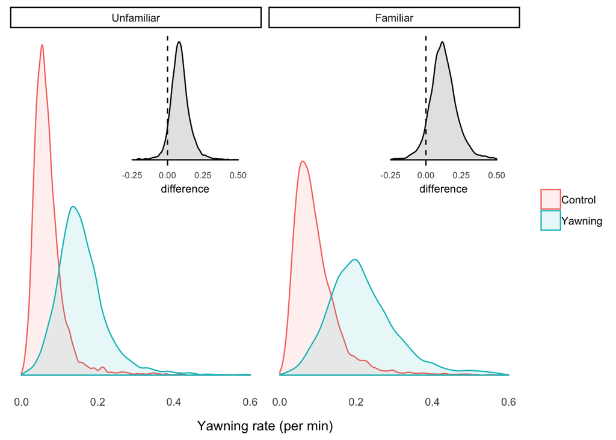

Let’s compare all models so far.

```r
loo_compare(m1.1, m1.2, m1.3, m1.4, m1.5)
```

```
##      elpd_diff se_diff
## m1.4   0.0       0.0
## m1.2  -0.3       1.6
## m1.5  -1.0       0.6
## m1.3 -30.2       6.7
## m1.1 -31.9       7.0
```

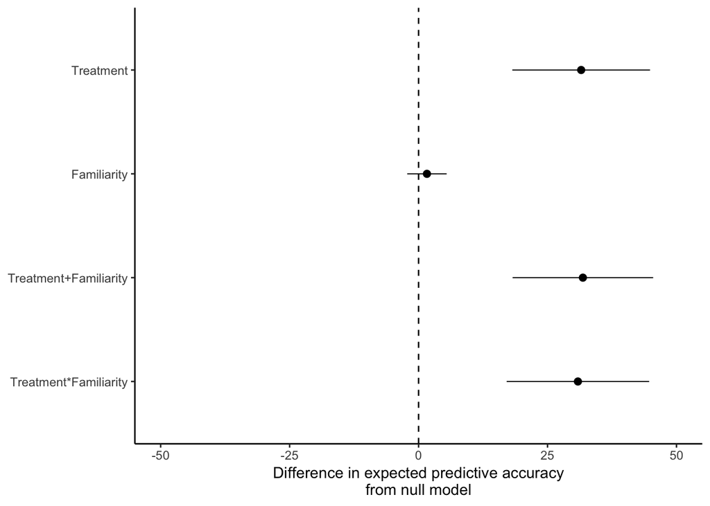

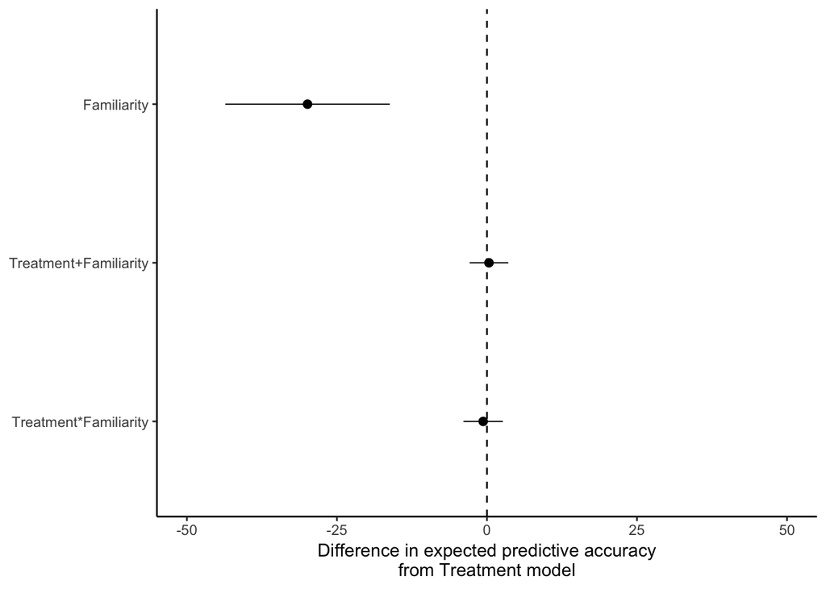

The best models are `m1.2`, `m1.4`, and `m1.5` - all the models that have a condition parameter. None of these models are substantially better than one another. This suggests that condition has an effect, but familiarity doesn’t interact with it.

Going forward, we choose the condition-only model to continue analysing, as the most parsmionious model. Next, we add controls to see if the effect of condition is robust.

## 1.6. Condition + Type model

We include both condition and type (shelter/pet) as additive effects.

```
##  Family: zero_inflated_poisson
##   Links: mu = log; zi = logit
## Formula: numberYawns ~ 0 + intercept + condition + type + offset(log(secs)) + (0 + intercept + condition | study/ID)
##          zi ~ 0 + intercept + condition + type + (0 + intercept + condition | study/ID)
##    Data: d (Number of observations: 686)
## Samples: 4 chains, each with iter = 3000; warmup = 1500; thin = 1;
##          total post-warmup samples = 6000
##
## Group-Level Effects:
## ~study (Number of levels: 6)
##                                Estimate Est.Error l-95% CI u-95% CI Rhat Bulk_ESS Tail_ESS
## sd(intercept)                      1.29      0.77     0.31     3.28 1.00     1614     1639
## sd(condition)                      1.53      0.77     0.56     3.52 1.00     1793     2840
## sd(zi_intercept)                   0.64      0.55     0.02     1.97 1.00     1720     1894
## sd(zi_condition)                   0.90      0.66     0.05     2.49 1.00     2356     3301
## cor(intercept,condition)          -0.72      0.31    -0.99     0.16 1.00     2260     2929
## cor(zi_intercept,zi_condition)     0.17      0.54    -0.90     0.96 1.00     2818     3394
##
## ~study:ID (Number of levels: 197)
##                                Estimate Est.Error l-95% CI u-95% CI Rhat Bulk_ESS Tail_ESS
## sd(intercept)                      0.61      0.16     0.31     0.93 1.01      909     1374
## sd(condition)                      0.23      0.17     0.01     0.60 1.00     1104     2191
## sd(zi_intercept)                   0.69      0.61     0.02     2.25 1.01      562     1085
## sd(zi_condition)                   0.38      0.31     0.01     1.16 1.00     3131     3628
## cor(intercept,condition)          -0.36      0.51    -0.98     0.84 1.00     3005     3569
## cor(zi_intercept,zi_condition)    -0.01      0.58    -0.95     0.95 1.00     5487     4043
##
## Population-Level Effects:
##              Estimate Est.Error l-95% CI u-95% CI Rhat Bulk_ESS Tail_ESS
## intercept       -6.88      0.62    -8.10    -5.62 1.00     1682     2385
## condition        0.93      0.56    -0.26     1.99 1.00     2493     2902
## type             0.07      0.42    -0.76     0.87 1.00     3235     3655
## zi_intercept    -1.25      0.80    -2.97     0.21 1.00     2016     3371
## zi_condition    -0.15      0.67    -1.46     1.18 1.00     4264     4254
## zi_type         -0.22      0.65    -1.53     1.08 1.00     4610     4489
##
## Samples were drawn using sampling(NUTS). For each parameter, Eff.Sample
## is a crude measure of effective sample size, and Rhat is the potential
## scale reduction factor on split chains (at convergence, Rhat = 1).
```

What priors did we use?

| prior | class | coef | group | resp | dpar | nlpar | bound |
| --- | --- | --- | --- | --- | --- | --- | --- |
|  | b |  |  |  |  |  |  |
| normal(0, 1) | b | condition |  |  |  |  |  |
| student_t(3, -2, 10) | b | intercept |  |  |  |  |  |
| normal(0, 1) | b | type |  |  |  |  |  |
|  | b |  |  |  | zi |  |  |
| normal(0, 1) | b | condition |  |  | zi |  |  |
| logistic(0, 1) | b | intercept |  |  | zi |  |  |
| normal(0, 1) | b | type |  |  | zi |  |  |
| lkj_corr_cholesky(1) | L |  |  |  |  |  |  |
|  | L |  | study |  |  |  |  |

[output cut: 15 more lines]

Effect of condition?

```r
post <- posterior_samples(m1.6)
(sum(post$b_condition > 0) / length(post$b_condition)) %>% round(2)
```

```
## [1] 0.95
```

Similar to before. Model comparison.

```r
loo_compare(m1.2, m1.6)
```

```
##      elpd_diff se_diff
## m1.2  0.0       0.0
## m1.6 -0.9       0.8
```

## 1.7. Condition + Presentation model

```
##  Family: zero_inflated_poisson
##   Links: mu = log; zi = logit
## Formula: numberYawns ~ 0 + intercept + condition + presentation + offset(log(secs)) + (0 + intercept + condition | study/ID)
##          zi ~ 0 + intercept + condition + presentation + (0 + intercept + condition | study/ID)
##    Data: d (Number of observations: 686)
## Samples: 4 chains, each with iter = 2000; warmup = 1000; thin = 1;
##          total post-warmup samples = 4000
##
## Group-Level Effects:
## ~study (Number of levels: 6)
##                                Estimate Est.Error l-95% CI u-95% CI Rhat Bulk_ESS Tail_ESS
## sd(intercept)                      1.11      0.67     0.29     2.75 1.01      808      640
## sd(condition)                      1.45      0.74     0.52     3.37 1.01      892      854
## sd(zi_intercept)                   0.57      0.48     0.02     1.78 1.00     1269     2107
## sd(zi_condition)                   0.85      0.63     0.03     2.41 1.00     1143     1528
## cor(intercept,condition)          -0.84      0.25    -1.00    -0.04 1.01     1053     1347
## cor(zi_intercept,zi_condition)     0.11      0.56    -0.93     0.96 1.00     1493     1783
##
## ~study:ID (Number of levels: 197)
##                                Estimate Est.Error l-95% CI u-95% CI Rhat Bulk_ESS Tail_ESS
## sd(intercept)                      0.62      0.15     0.33     0.93 1.00      582      602
## sd(condition)                      0.23      0.16     0.01     0.61 1.00      529     1326
## sd(zi_intercept)                   0.63      0.55     0.02     2.02 1.01      465      852
## sd(zi_condition)                   0.34      0.28     0.01     1.04 1.00     2178     1730
## cor(intercept,condition)          -0.35      0.52    -0.98     0.86 1.00     1753     2027
## cor(zi_intercept,zi_condition)    -0.06      0.58    -0.95     0.94 1.00     3110     2552
##
## Population-Level Effects:
##                 Estimate Est.Error l-95% CI u-95% CI Rhat Bulk_ESS Tail_ESS
## intercept          -6.20      0.57    -7.34    -5.10 1.00      922     1754
## condition           0.93      0.56    -0.27     1.98 1.00     1065     1953
## presentation       -0.79      0.37    -1.48    -0.06 1.00     1728     2506
## zi_intercept       -0.75      0.86    -2.66     0.80 1.01     1177     2075
## zi_condition       -0.11      0.68    -1.41     1.31 1.00     2036     1998
## zi_presentation    -0.82      0.66    -2.16     0.44 1.00     1903     2306
##
## Samples were drawn using sampling(NUTS). For each parameter, Eff.Sample
## is a crude measure of effective sample size, and Rhat is the potential
## scale reduction factor on split chains (at convergence, Rhat = 1).
```

Priors.

| prior | class | coef | group | resp | dpar | nlpar | bound |
| --- | --- | --- | --- | --- | --- | --- | --- |
|  | b |  |  |  |  |  |  |
| normal(0, 1) | b | condition |  |  |  |  |  |
| student_t(3, -2, 10) | b | intercept |  |  |  |  |  |
| normal(0, 1) | b | presentation |  |  |  |  |  |
|  | b |  |  |  | zi |  |  |
| normal(0, 1) | b | condition |  |  | zi |  |  |
| logistic(0, 1) | b | intercept |  |  | zi |  |  |
| normal(0, 1) | b | presentation |  |  | zi |  |  |
| lkj_corr_cholesky(1) | L |  |  |  |  |  |  |
|  | L |  | study |  |  |  |  |

[output cut: 15 more lines]

The effect of condition persists when controlling for presentation type (video and audio or audio-only).

```r
post <- posterior_samples(m1.7)
(sum(post$b_condition > 0) / length(post$b_condition)) %>% round(2)
```

```
## [1] 0.95
```

Model comparison.

```r
loo_compare(m1.2, m1.7)
```

```
##      elpd_diff se_diff
## m1.7  0.0       0.0
## m1.2 -1.8       1.8
```

## 1.8. Condition + Live model

```
##  Family: zero_inflated_poisson
##   Links: mu = log; zi = logit
## Formula: numberYawns ~ 0 + intercept + condition + live + offset(log(secs)) + (0 + intercept + condition | study/ID)
##          zi ~ 0 + intercept + condition + live + (0 + intercept + condition | study/ID)
##    Data: d (Number of observations: 686)
## Samples: 4 chains, each with iter = 2000; warmup = 1000; thin = 1;
##          total post-warmup samples = 4000
##
## Group-Level Effects:
## ~study (Number of levels: 6)
##                                Estimate Est.Error l-95% CI u-95% CI Rhat Bulk_ESS Tail_ESS
## sd(intercept)                      1.14      0.70     0.30     2.97 1.00     1187     1592
## sd(condition)                      1.46      0.78     0.53     3.39 1.00     1311     1716
## sd(zi_intercept)                   0.58      0.51     0.02     1.85 1.00     1229     1891
## sd(zi_condition)                   0.76      0.61     0.03     2.28 1.00     1644     1811
## cor(intercept,condition)          -0.81      0.26    -1.00    -0.05 1.00     1439     2248
## cor(zi_intercept,zi_condition)     0.11      0.56    -0.92     0.97 1.00     2196     2467
##
## ~study:ID (Number of levels: 197)
##                                Estimate Est.Error l-95% CI u-95% CI Rhat Bulk_ESS Tail_ESS
## sd(intercept)                      0.61      0.17     0.26     0.95 1.01      465      441
## sd(condition)                      0.24      0.17     0.01     0.63 1.00      857     1641
## sd(zi_intercept)                   0.63      0.58     0.02     2.11 1.00      414      939
## sd(zi_condition)                   0.37      0.30     0.01     1.14 1.00     2018     2146
## cor(intercept,condition)          -0.38      0.50    -0.97     0.80 1.00     2548     2557
## cor(zi_intercept,zi_condition)    -0.06      0.57    -0.96     0.92 1.00     3167     2943
##
## Population-Level Effects:
##              Estimate Est.Error l-95% CI u-95% CI Rhat Bulk_ESS Tail_ESS
## intercept       -6.42      0.57    -7.54    -5.27 1.00     1529     1902
## condition        0.90      0.56    -0.32     1.94 1.00     1661     1716
## live            -0.52      0.36    -1.18     0.25 1.00     2175     2500
## zi_intercept    -0.79      0.85    -2.55     0.71 1.00     1662     2508
## zi_condition    -0.13      0.68    -1.47     1.24 1.00     2451     2927
## zi_live         -0.79      0.66    -2.15     0.49 1.00     3149     3333
##
## Samples were drawn using sampling(NUTS). For each parameter, Eff.Sample
## is a crude measure of effective sample size, and Rhat is the potential
## scale reduction factor on split chains (at convergence, Rhat = 1).
```

Priors.

| prior | class | coef | group | resp | dpar | nlpar | bound |
| --- | --- | --- | --- | --- | --- | --- | --- |
|  | b |  |  |  |  |  |  |
| normal(0, 1) | b | condition |  |  |  |  |  |
| student_t(3, -2, 10) | b | intercept |  |  |  |  |  |
| normal(0, 1) | b | live |  |  |  |  |  |
|  | b |  |  |  | zi |  |  |
| normal(0, 1) | b | condition |  |  | zi |  |  |
| logistic(0, 1) | b | intercept |  |  | zi |  |  |
| normal(0, 1) | b | live |  |  | zi |  |  |
| lkj_corr_cholesky(1) | L |  |  |  |  |  |  |
|  | L |  | study |  |  |  |  |

[output cut: 15 more lines]

The effect of condition persists when controlling for whether the demonstration was live or recorded.

```r
post <- posterior_samples(m1.8)
(sum(post$b_condition > 0) / length(post$b_condition)) %>% round(2)
```

```
## [1] 0.94
```

Model comparison.

```r
loo_compare(m1.2, m1.8)
```

```
##      elpd_diff se_diff
## m1.2  0.0       0.0
## m1.8 -1.0       1.5
```

## 1.9. Condition + Demonstrator model

```
##  Family: zero_inflated_poisson
##   Links: mu = log; zi = logit
## Formula: numberYawns ~ 0 + intercept + condition + demonstrator + offset(log(secs)) + (0 + intercept + condition | study/ID)
##          zi ~ 0 + intercept + condition + demonstrator + (0 + intercept + condition | study/ID)
##    Data: d (Number of observations: 686)
## Samples: 4 chains, each with iter = 3000; warmup = 1500; thin = 1;
##          total post-warmup samples = 6000
##
## Group-Level Effects:
## ~study (Number of levels: 6)
##                                Estimate Est.Error l-95% CI u-95% CI Rhat Bulk_ESS Tail_ESS
## sd(intercept)                      1.23      0.75     0.28     3.11 1.00     1372     1494
## sd(condition)                      1.51      0.80     0.55     3.55 1.00     1666     2313
## sd(zi_intercept)                   0.60      0.51     0.02     1.87 1.00     1703     3322
## sd(zi_condition)                   0.90      0.67     0.04     2.50 1.00     1980     2568
## cor(intercept,condition)          -0.70      0.33    -0.99     0.21 1.00     2304     2838
## cor(zi_intercept,zi_condition)     0.13      0.55    -0.90     0.96 1.00     2397     3488
##
## ~study:ID (Number of levels: 197)
##                                Estimate Est.Error l-95% CI u-95% CI Rhat Bulk_ESS Tail_ESS
## sd(intercept)                      0.60      0.17     0.24     0.92 1.01      529      573
## sd(condition)                      0.22      0.16     0.01     0.61 1.01     1538     2595
## sd(zi_intercept)                   0.68      0.60     0.02     2.15 1.01      563     1506
## sd(zi_condition)                   0.36      0.32     0.01     1.18 1.00     2804     3397
## cor(intercept,condition)          -0.34      0.53    -0.98     0.87 1.00     3502     3678
## cor(zi_intercept,zi_condition)    -0.02      0.58    -0.95     0.95 1.00     5829     4376
##
## Population-Level Effects:
##                 Estimate Est.Error l-95% CI u-95% CI Rhat Bulk_ESS Tail_ESS
## intercept          -6.82      0.56    -7.90    -5.62 1.00     1494     1997
## condition           0.92      0.58    -0.37     1.97 1.00     2263     2739
## demonstrator       -0.28      0.44    -1.16     0.58 1.00     6246     4657
## zi_intercept       -1.30      0.70    -2.84    -0.07 1.00     1720     3196
## zi_condition       -0.21      0.68    -1.55     1.09 1.00     3810     4033
## zi_demonstrator    -0.07      0.79    -1.70     1.43 1.00     5781     4546
##
## Samples were drawn using sampling(NUTS). For each parameter, Eff.Sample
## is a crude measure of effective sample size, and Rhat is the potential
## scale reduction factor on split chains (at convergence, Rhat = 1).
```

Priors.

| prior | class | coef | group | resp | dpar | nlpar | bound |
| --- | --- | --- | --- | --- | --- | --- | --- |
|  | b |  |  |  |  |  |  |
| normal(0, 1) | b | condition |  |  |  |  |  |
| normal(0, 1) | b | demonstrator |  |  |  |  |  |
| student_t(3, -2, 10) | b | intercept |  |  |  |  |  |
|  | b |  |  |  | zi |  |  |
| normal(0, 1) | b | condition |  |  | zi |  |  |
| normal(0, 1) | b | demonstrator |  |  | zi |  |  |
| logistic(0, 1) | b | intercept |  |  | zi |  |  |
| lkj_corr_cholesky(1) | L |  |  |  |  |  |  |
|  | L |  | study |  |  |  |  |

[output cut: 15 more lines]

The effect of condition persists.

```r
post <- posterior_samples(m1.9)
(sum(post$b_condition > 0) / length(post$b_condition)) %>% round(2)
```

```
## [1] 0.94
```

Model comparison.

```r
loo_compare(m1.2, m1.9)
```

```
##      elpd_diff se_diff
## m1.2  0.0       0.0
## m1.9 -1.4       1.4
```

## 1.10. Full model (all controls)

```
##  Family: zero_inflated_poisson
##   Links: mu = log; zi = logit
## Formula: numberYawns ~ 0 + intercept + condition + presentation + type + demonstrator + familiar + live + offset(log(secs)) + (0 + intercept + condition | study/ID)
##          zi ~ 0 + intercept + condition + presentation + type + demonstrator + familiar + live + (0 + intercept + condition | study/ID)
##    Data: d (Number of observations: 686)
## Samples: 4 chains, each with iter = 3000; warmup = 1500; thin = 1;
##          total post-warmup samples = 6000
##
## Group-Level Effects:
## ~study (Number of levels: 6)
##                                Estimate Est.Error l-95% CI u-95% CI Rhat Bulk_ESS Tail_ESS
## sd(intercept)                      1.05      0.66     0.20     2.74 1.00     1556     1663
## sd(condition)                      1.51      0.76     0.57     3.39 1.00     1656     2046
## sd(zi_intercept)                   0.78      0.63     0.03     2.28 1.00     1186     2544
## sd(zi_condition)                   0.62      0.55     0.02     2.02 1.00     2154     2229
## cor(intercept,condition)          -0.73      0.33    -1.00     0.22 1.00     1557     1732
## cor(zi_intercept,zi_condition)     0.13      0.56    -0.93     0.96 1.00     3622     3864
##
## ~study:ID (Number of levels: 197)
##                                Estimate Est.Error l-95% CI u-95% CI Rhat Bulk_ESS Tail_ESS
## sd(intercept)                      0.60      0.16     0.27     0.92 1.00      732      916
## sd(condition)                      0.23      0.17     0.01     0.64 1.00      863     1417
## sd(zi_intercept)                   0.73      0.65     0.02     2.42 1.01      390      730
## sd(zi_condition)                   0.37      0.31     0.01     1.18 1.00     2678     3005
## cor(intercept,condition)          -0.31      0.53    -0.97     0.88 1.00     2695     3277
## cor(zi_intercept,zi_condition)    -0.04      0.58    -0.96     0.95 1.00     4185     3708
##
## Population-Level Effects:
##                 Estimate Est.Error l-95% CI u-95% CI Rhat Bulk_ESS Tail_ESS
## intercept          -5.77      0.75    -7.30    -4.27 1.00     1720     3052
## condition           0.86      0.57    -0.38     1.91 1.00     2158     2568
## presentation       -0.66      0.65    -1.96     0.61 1.00     3052     3973
## type               -0.45      0.45    -1.32     0.43 1.00     1894     3251
## demonstrator       -0.29      0.66    -1.57     1.01 1.00     3410     3985
## familiar            0.28      0.20    -0.12     0.67 1.00     2669     3567
## live               -0.33      0.62    -1.51     0.90 1.00     3168     3719
## zi_intercept       -0.08      1.01    -2.16     1.80 1.00     2558     2977
## zi_condition       -0.22      0.66    -1.52     1.14 1.00     3346     4217
## zi_presentation    -0.74      0.79    -2.34     0.80 1.00     3821     3883
## zi_type            -0.83      0.66    -2.11     0.47 1.00     4077     4393
## zi_demonstrator    -0.14      0.84    -1.83     1.51 1.00     5745     4416
## zi_familiar         0.65      0.76    -1.09     2.00 1.00     2200     2226
## zi_live            -0.61      0.79    -2.15     0.92 1.00     4192     4416
##
## Samples were drawn using sampling(NUTS). For each parameter, Eff.Sample
## is a crude measure of effective sample size, and Rhat is the potential
## scale reduction factor on split chains (at convergence, Rhat = 1).
```

Priors.

| prior | class | coef | group | resp | dpar | nlpar | bound |
| --- | --- | --- | --- | --- | --- | --- | --- |
|  | b |  |  |  |  |  |  |
| normal(0, 1) | b | condition |  |  |  |  |  |
| normal(0, 1) | b | demonstrator |  |  |  |  |  |
| normal(0, 1) | b | familiar |  |  |  |  |  |
| student_t(3, -2, 10) | b | intercept |  |  |  |  |  |
| normal(0, 1) | b | live |  |  |  |  |  |
| normal(0, 1) | b | presentation |  |  |  |  |  |
| normal(0, 1) | b | type |  |  |  |  |  |
|  | b |  |  |  | zi |  |  |
| normal(0, 1) | b | condition |  |  | zi |  |  |

[output cut: 23 more lines]

```r
post <- posterior_samples(m1.10)
(sum(post$b_condition > 0) / length(post$b_condition)) %>% round(2)
```

```
## [1] 0.93
```

Model comparison.

```r
loo_compare(m1.2, m1.6, m1.7, m1.8, m1.9, m1.10)
```

```
##       elpd_diff se_diff
## m1.7   0.0       0.0
## m1.2  -1.8       1.8
## m1.6  -2.7       1.8
## m1.10 -2.8       1.7
## m1.8  -2.8       1.7
## m1.9  -3.2       1.9
```

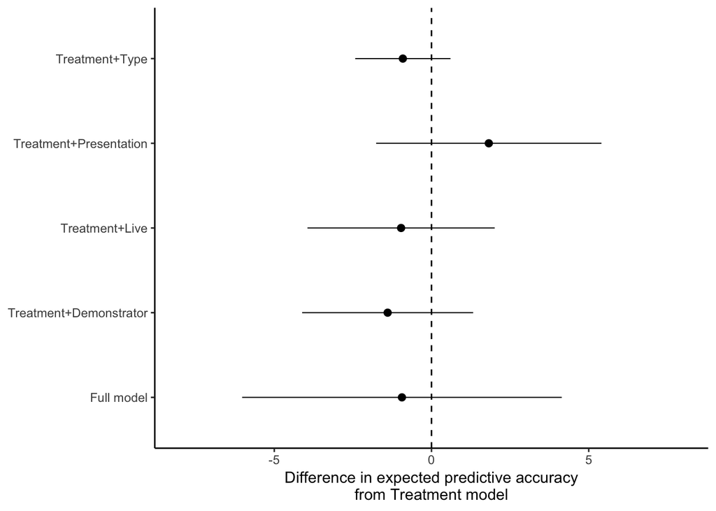

Plot condition parameter with controls.

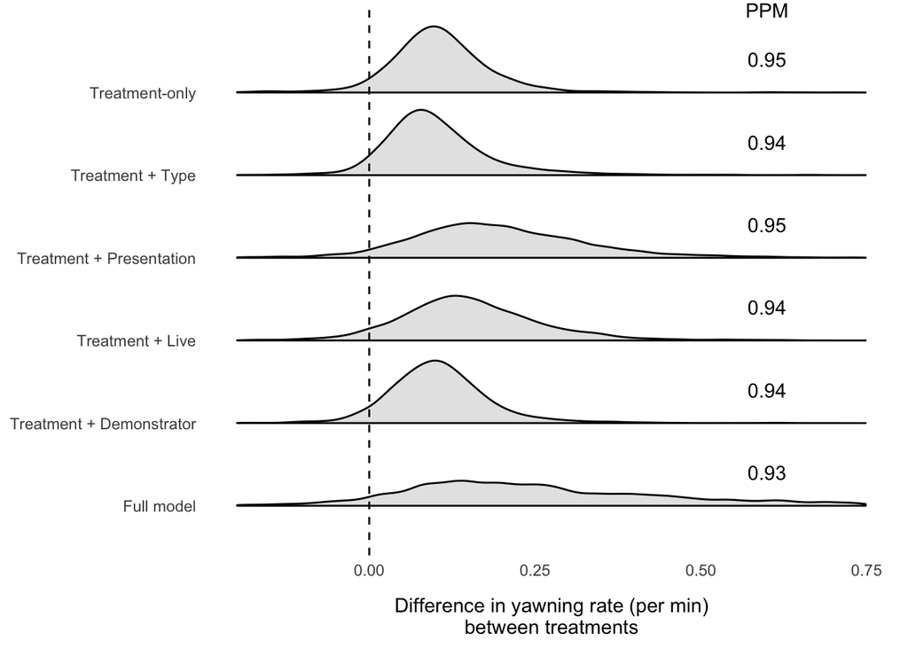

## 1.11. Gender-only model

```
##  Family: zero_inflated_poisson
##   Links: mu = log; zi = logit
## Formula: numberYawns ~ 0 + intercept + male + offset(log(secs)) + (0 + intercept + male | study) + (0 + intercept | study:ID)
##          zi ~ 0 + intercept + male + (0 + intercept + male | study) + (0 + intercept | study:ID)
##    Data: d (Number of observations: 686)
## Samples: 4 chains, each with iter = 2000; warmup = 1000; thin = 1;
##          total post-warmup samples = 4000
##
## Group-Level Effects:
## ~study (Number of levels: 6)
##                           Estimate Est.Error l-95% CI u-95% CI Rhat Bulk_ESS Tail_ESS
## sd(intercept)                 0.43      0.36     0.02     1.34 1.00     1121     1714
## sd(male)                      0.57      0.41     0.05     1.62 1.00     1376     1677
## sd(zi_intercept)              0.81      0.42     0.13     1.82 1.00     1280      858
## sd(zi_male)                   0.37      0.33     0.01     1.19 1.00     2663     2010
## cor(intercept,male)           0.14      0.52    -0.86     0.96 1.00     1679     2447
## cor(zi_intercept,zi_male)     0.11      0.56    -0.92     0.96 1.00     3872     2758
##
## ~study:ID (Number of levels: 197)
##                  Estimate Est.Error l-95% CI u-95% CI Rhat Bulk_ESS Tail_ESS
## sd(intercept)        0.54      0.12     0.29     0.76 1.00      638     1013
## sd(zi_intercept)     0.51      0.39     0.02     1.46 1.01      659     1054
##
## Population-Level Effects:
##              Estimate Est.Error l-95% CI u-95% CI Rhat Bulk_ESS Tail_ESS
## intercept       -5.90      0.29    -6.45    -5.29 1.00     1245     1324
## male            -0.11      0.30    -0.69     0.52 1.00     1996     1970
## zi_intercept    -0.47      0.49    -1.49     0.49 1.00     1790     2477
## zi_male         -0.41      0.46    -1.33     0.49 1.00     2977     2941
##
## Samples were drawn using sampling(NUTS). For each parameter, Eff.Sample
## is a crude measure of effective sample size, and Rhat is the potential
## scale reduction factor on split chains (at convergence, Rhat = 1).
```

Priors.

| prior | class | coef | group | resp | dpar | nlpar | bound |
| --- | --- | --- | --- | --- | --- | --- | --- |
|  | b |  |  |  |  |  |  |
| student_t(3, -2, 10) | b | intercept |  |  |  |  |  |
| normal(0, 1) | b | male |  |  |  |  |  |
|  | b |  |  |  | zi |  |  |
| logistic(0, 1) | b | intercept |  |  | zi |  |  |
| normal(0, 1) | b | male |  |  | zi |  |  |
| lkj_corr_cholesky(1) | L |  |  |  |  |  |  |
|  | L |  | study |  |  |  |  |
| student_t(3, 0, 10) | sd |  |  |  |  |  |  |
| student_t(3, 0, 0.5) | sd |  |  |  | zi |  |  |

[output cut: 10 more lines]

## 1.12. Condition + Gender model

```
##  Family: zero_inflated_poisson
##   Links: mu = log; zi = logit
## Formula: numberYawns ~ 0 + intercept + condition + male + offset(log(secs)) + (0 + intercept + condition + male | study) + (0 + intercept + condition | study:ID)
##          zi ~ 0 + intercept + condition + male + (0 + intercept + condition + male | study) + (0 + intercept + condition | study:ID)
##    Data: d (Number of observations: 686)
## Samples: 4 chains, each with iter = 2000; warmup = 1000; thin = 1;
##          total post-warmup samples = 4000
##
## Group-Level Effects:
## ~study (Number of levels: 6)
##                                Estimate Est.Error l-95% CI u-95% CI Rhat Bulk_ESS Tail_ESS
## sd(intercept)                      1.17      0.67     0.30     2.85 1.00      940     1018
## sd(condition)                      1.45      0.76     0.54     3.32 1.00     1155     1569
## sd(male)                           0.54      0.41     0.03     1.58 1.00     1316     1690
## sd(zi_intercept)                   0.57      0.50     0.02     1.82 1.00     1593     1833
## sd(zi_condition)                   0.84      0.64     0.04     2.33 1.00     1322     1921
## sd(zi_male)                        0.44      0.40     0.02     1.44 1.00     2841     2353
## cor(intercept,condition)          -0.65      0.32    -0.98     0.18 1.00     1982     2234
## cor(intercept,male)               -0.03      0.44    -0.83     0.76 1.00     3815     2785
## cor(condition,male)                0.11      0.43    -0.75     0.86 1.00     3417     2763
## cor(zi_intercept,zi_condition)     0.09      0.48    -0.82     0.90 1.00     2846     2354
## cor(zi_intercept,zi_male)          0.04      0.51    -0.88     0.89 1.00     3637     2575
## cor(zi_condition,zi_male)          0.11      0.49    -0.83     0.90 1.00     4413     3187
##
## ~study:ID (Number of levels: 197)
##                                Estimate Est.Error l-95% CI u-95% CI Rhat Bulk_ESS Tail_ESS
## sd(intercept)                      0.58      0.16     0.27     0.89 1.00      639      861
## sd(condition)                      0.21      0.16     0.01     0.60 1.01      773     1019
## sd(zi_intercept)                   0.67      0.58     0.02     2.19 1.00      392     1171
## sd(zi_condition)                   0.37      0.32     0.01     1.19 1.00     1848     1892
## cor(intercept,condition)          -0.30      0.53    -0.97     0.87 1.00     2478     2552
## cor(zi_intercept,zi_condition)    -0.02      0.58    -0.95     0.95 1.00     3259     2544
##
## Population-Level Effects:
##              Estimate Est.Error l-95% CI u-95% CI Rhat Bulk_ESS Tail_ESS
## intercept       -6.80      0.52    -7.86    -5.76 1.00     1457     1539
## condition        0.90      0.53    -0.27     1.90 1.00     2051     2088
## male            -0.07      0.30    -0.68     0.55 1.00     2391     2024
## zi_intercept    -1.17      0.77    -2.92     0.14 1.00     1406     1774
## zi_condition    -0.20      0.68    -1.55     1.12 1.00     2918     2580
## zi_male         -0.37      0.57    -1.56     0.72 1.00     3280     3217
##
## Samples were drawn using sampling(NUTS). For each parameter, Eff.Sample
## is a crude measure of effective sample size, and Rhat is the potential
## scale reduction factor on split chains (at convergence, Rhat = 1).
```

Priors.

| prior | class | coef | group | resp | dpar | nlpar | bound |
| --- | --- | --- | --- | --- | --- | --- | --- |
|  | b |  |  |  |  |  |  |
| normal(0, 1) | b | condition |  |  |  |  |  |
| student_t(3, -2, 10) | b | intercept |  |  |  |  |  |
| normal(0, 1) | b | male |  |  |  |  |  |
|  | b |  |  |  | zi |  |  |
| normal(0, 1) | b | condition |  |  | zi |  |  |
| logistic(0, 1) | b | intercept |  |  | zi |  |  |
| normal(0, 1) | b | male |  |  | zi |  |  |
| lkj_corr_cholesky(1) | L |  |  |  |  |  |  |
|  | L |  | study |  |  |  |  |

[output cut: 17 more lines]

Get difference between conditions, controlling for gender.

```r
post <- posterior_samples(m1.12)

# yawning rates (per minute)
cond1 <- exp(post$b_intercept) * 60
median(cond1) %>% round(2)
```

```
## [1] 0.07
```

```r
cond2 <- exp(post$b_intercept + post$b_condition) * 60
median(cond2) %>% round(2)
```

```
## [1] 0.17
```

```r
diff <- cond2 - cond1

# proportion of prob mass above zero
(sum(diff > 0) / length(diff)) %>% round(2)
```

```
## [1] 0.95
```

## 1.13. Condition*Gender model

```
##  Family: zero_inflated_poisson
##   Links: mu = log; zi = logit
## Formula: numberYawns ~ 0 + intercept + condition * male + offset(log(secs)) + (0 + intercept + condition * male | study) + (0 + intercept + condition | study:ID)
##          zi ~ 0 + intercept + condition * male + (0 + intercept + condition * male | study) + (0 + intercept + condition | study:ID)
##    Data: d (Number of observations: 686)
## Samples: 4 chains, each with iter = 2000; warmup = 1000; thin = 1;
##          total post-warmup samples = 4000
##
## Group-Level Effects:
## ~study (Number of levels: 6)
##                                     Estimate Est.Error l-95% CI u-95% CI Rhat Bulk_ESS Tail_ESS
## sd(intercept)                           1.14      0.73     0.23     3.04 1.01      868      856
## sd(condition)                           1.39      0.75     0.47     3.41 1.01     1000     1312
## sd(male)                                0.66      0.49     0.04     1.81 1.00     1264     1287
## sd(condition:male)                      0.38      0.36     0.01     1.34 1.00     1773     1527
## sd(zi_intercept)                        0.60      0.52     0.02     1.90 1.00     1256     2083
## sd(zi_condition)                        0.77      0.63     0.03     2.33 1.00     1602     2188
## sd(zi_male)                             0.45      0.42     0.02     1.49 1.00     2872     2229
## sd(zi_condition:male)                   0.51      0.48     0.02     1.75 1.00     3262     2788
## cor(intercept,condition)               -0.55      0.34    -0.96     0.28 1.00     1909     2352
## cor(intercept,male)                    -0.03      0.41    -0.77     0.74 1.00     3732     2938
## cor(condition,male)                     0.08      0.39    -0.69     0.79 1.00     4191     3378
## cor(intercept,condition:male)          -0.02      0.45    -0.81     0.80 1.00     6227     3315
## cor(condition,condition:male)           0.02      0.44    -0.80     0.81 1.00     4559     2609
## cor(male,condition:male)               -0.14      0.45    -0.88     0.75 1.00     3313     3301
## cor(zi_intercept,zi_condition)          0.05      0.45    -0.77     0.84 1.00     2873     2929
## cor(zi_intercept,zi_male)               0.02      0.44    -0.78     0.80 1.00     5510     2945
## cor(zi_condition,zi_male)               0.06      0.45    -0.80     0.84 1.00     4857     2822
## cor(zi_intercept,zi_condition:male)     0.04      0.44    -0.79     0.83 1.00     5698     2987
## cor(zi_condition,zi_condition:male)     0.07      0.44    -0.76     0.82 1.00     3693     2963
## cor(zi_male,zi_condition:male)         -0.00      0.44    -0.80     0.82 1.00     3134     3179
##
## ~study:ID (Number of levels: 197)
##                                Estimate Est.Error l-95% CI u-95% CI Rhat Bulk_ESS Tail_ESS
## sd(intercept)                      0.57      0.18     0.14     0.91 1.01      327      235
## sd(condition)                      0.22      0.17     0.01     0.61 1.01      715     1287
## sd(zi_intercept)                   0.68      0.59     0.03     2.12 1.01      578     1024
## sd(zi_condition)                   0.38      0.33     0.02     1.23 1.00     1865     2431
## cor(intercept,condition)          -0.30      0.54    -0.97     0.89 1.00     1601     2572
## cor(zi_intercept,zi_condition)    -0.01      0.58    -0.95     0.94 1.00     3568     3156
##
## Population-Level Effects:
##                   Estimate Est.Error l-95% CI u-95% CI Rhat Bulk_ESS Tail_ESS
## intercept            -6.84      0.57    -8.00    -5.74 1.00     1157     1498
## condition             0.91      0.54    -0.24     1.94 1.00     1734     2091
## male                 -0.05      0.39    -0.79     0.79 1.00     2148     2188
## condition:male       -0.02      0.34    -0.67     0.65 1.00     2580     2253
## zi_intercept         -1.13      0.77    -2.81     0.25 1.00     1446     2486
## zi_condition         -0.23      0.69    -1.58     1.14 1.00     3238     3130
## zi_male              -0.47      0.69    -1.84     0.84 1.00     3201     2991
## zi_condition:male    -0.01      0.74    -1.44     1.44 1.00     3867     3094
##
## Samples were drawn using sampling(NUTS). For each parameter, Eff.Sample
## is a crude measure of effective sample size, and Rhat is the potential
## scale reduction factor on split chains (at convergence, Rhat = 1).
```

Priors.

| prior | class | coef | group | resp | dpar | nlpar | bound |
| --- | --- | --- | --- | --- | --- | --- | --- |
|  | b |  |  |  |  |  |  |
| normal(0, 1) | b | condition |  |  |  |  |  |
| normal(0, 1) | b | condition:male |  |  |  |  |  |
| student_t(3, -2, 10) | b | intercept |  |  |  |  |  |
| normal(0, 1) | b | male |  |  |  |  |  |
|  | b |  |  |  | zi |  |  |
| normal(0, 1) | b | condition |  |  | zi |  |  |
| normal(0, 1) | b | condition:male |  |  | zi |  |  |
| logistic(0, 1) | b | intercept |  |  | zi |  |  |
| normal(0, 1) | b | male |  |  | zi |  |  |

[output cut: 21 more lines]

```r
post <- posterior_samples(m1.13)

# yawning rates (per minute)
cond1f <- exp(post$b_intercept) * 60
cond2f <- exp(post$b_intercept + post$b_condition) * 60
cond1m <- exp(post$b_intercept + post$b_male) * 60
cond2m <- exp(post$b_intercept + post$b_condition +
                    post$b_male + post$`b_condition:male`) * 60

median(cond1f) %>% round(2)
```

```
## [1] 0.06
```

```r
median(cond2f) %>% round(2)
```

```
## [1] 0.17
```

```r
median(cond1m) %>% round(2)
```

```
## [1] 0.06
```

```r
median(cond2m) %>% round(2)
```

```
## [1] 0.15
```

Are there any differences in yawning rate? Get proportions of prob mass above zero for each contrast.

```r
diff1 <- cond2m - cond1f
diff2 <- cond2m - cond2f
diff3 <- cond2m - cond1m
diff4 <- cond1m - cond1f
diff5 <- cond1m - cond2f
diff6 <- cond2f - cond1f

(sum(diff1 > 0) / length(diff1)) %>% round(2)
```

```
## [1] 0.91
```

```r
(sum(diff2 > 0) / length(diff2)) %>% round(2)
```

```
## [1] 0.41
```

```r
(sum(diff3 > 0) / length(diff3)) %>% round(2)
```

```
## [1] 0.93
```

```r
(sum(diff4 > 0) / length(diff4)) %>% round(2)
```

```
## [1] 0.43
```

```r
(sum(diff5 > 0) / length(diff5)) %>% round(2)
```

```
## [1] 0.07
```

```r
(sum(diff6 > 0) / length(diff6)) %>% round(2)
```

```
## [1] 0.95
```

Does the effect of condition differ between males and females? Interaction effect.

```r
(sum(diff3 - diff6 > 0) / length(diff3)) %>% round(2)
```

```
## [1] 0.44
```

Visualise.

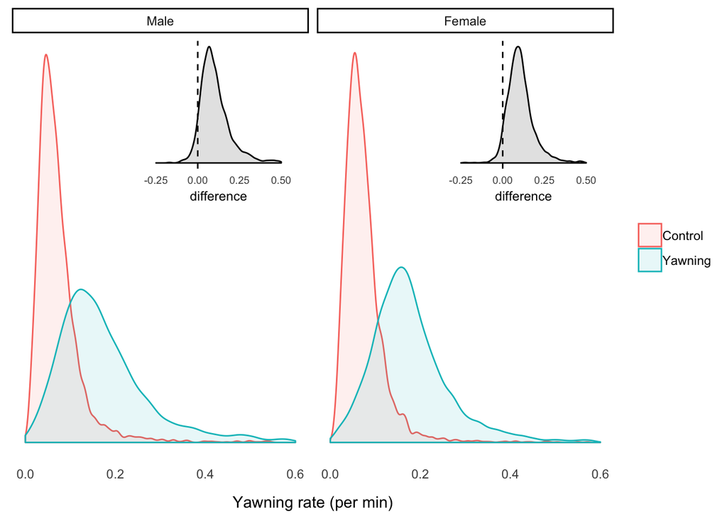

Let’s compare all the condition/gender models.

```r
loo_compare(m1.1, m1.2, m1.11, m1.12, m1.13)
```

```
##       elpd_diff se_diff
## m1.2    0.0       0.0
## m1.12  -1.1       1.5
## m1.13  -3.3       1.8
## m1.11 -30.8       7.1
## m1.1  -31.5       6.8
```

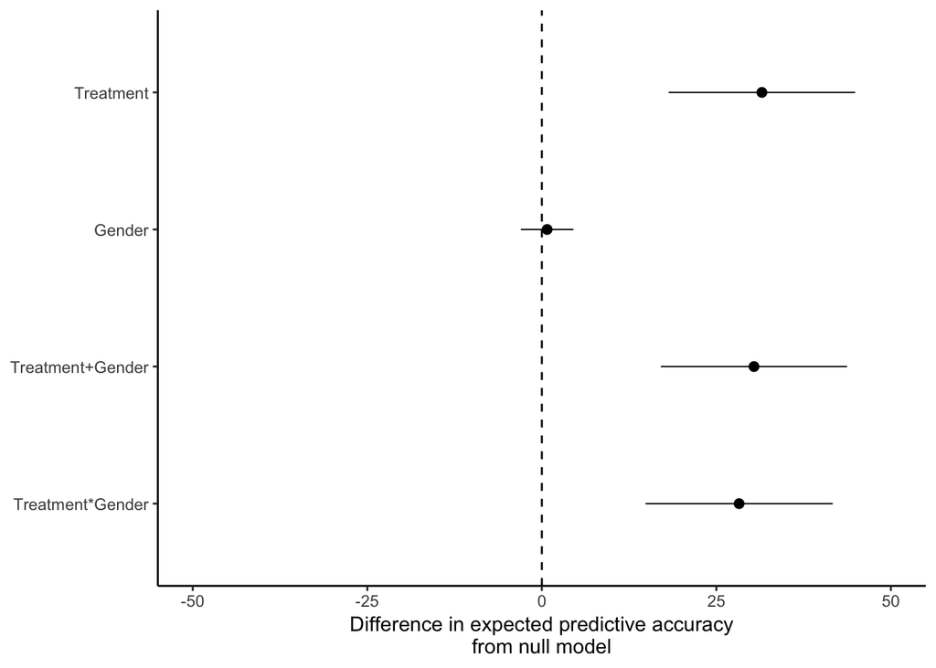

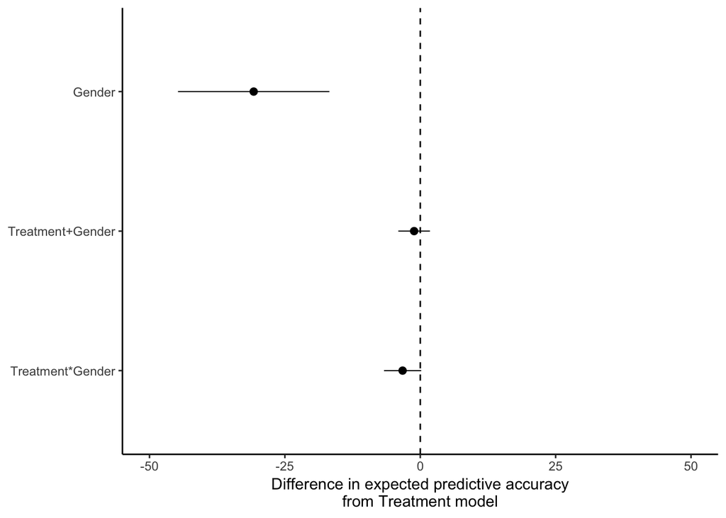

# 2. Fit Poisson models

## 2.1. Intercept-only model

We remove the assumption of zero-inflation and fit an intercept-only Poisson model.

```
##  Family: poisson
##   Links: mu = log
## Formula: numberYawns ~ 1 + offset(log(secs)) + (1 | study/ID)
##    Data: d (Number of observations: 686)
## Samples: 4 chains, each with iter = 2000; warmup = 1000; thin = 1;
##          total post-warmup samples = 4000
##
## Group-Level Effects:
## ~study (Number of levels: 6)
##               Estimate Est.Error l-95% CI u-95% CI Rhat Bulk_ESS Tail_ESS
## sd(Intercept)     0.44      0.30     0.05     1.20 1.00      857      912
##
## ~study:ID (Number of levels: 197)
##               Estimate Est.Error l-95% CI u-95% CI Rhat Bulk_ESS Tail_ESS
## sd(Intercept)     0.70      0.09     0.53     0.89 1.00     1598     2487
##
## Population-Level Effects:
##           Estimate Est.Error l-95% CI u-95% CI Rhat Bulk_ESS Tail_ESS
## Intercept    -6.53      0.23    -6.96    -6.04 1.00     1750     1841
##
## Samples were drawn using sampling(NUTS). For each parameter, Eff.Sample
## is a crude measure of effective sample size, and Rhat is the potential
## scale reduction factor on split chains (at convergence, Rhat = 1).
```

Priors.

| prior | class | coef | group | resp | dpar | nlpar | bound |
| --- | --- | --- | --- | --- | --- | --- | --- |
| student_t(3, -2, 10) | Intercept |  |  |  |  |  |  |
| student_t(3, 0, 10) | sd |  |  |  |  |  |  |
|  | sd |  | study |  |  |  |  |
|  | sd | Intercept | study |  |  |  |  |
|  | sd |  | study:ID |  |  |  |  |
|  | sd | Intercept | study:ID |  |  |  |  |

```r
post <- posterior_samples(m2.1)

(exp(post$b_Intercept) * 60) %>% # Yawning rate (per min)
  median() %>%
  round(2)
```

```
## [1] 0.09
```

The dogs yawn 0.09 times a minute, on average. Predictably, this is less than estimated by the zero-inflated model.

Model comparison?

```r
loo_compare(m1.1, m2.1)
```

```
##      elpd_diff se_diff
## m1.1   0.0       0.0
## m2.1 -25.5       7.4
```

The zero-inflated model is superior.

## 2.2. Condition-only model

```
##  Family: poisson
##   Links: mu = log
## Formula: numberYawns ~ 0 + intercept + condition + offset(log(secs)) + (0 + intercept + condition | study/ID)
##    Data: d (Number of observations: 686)
## Samples: 4 chains, each with iter = 2000; warmup = 1000; thin = 1;
##          total post-warmup samples = 4000
##
## Group-Level Effects:
## ~study (Number of levels: 6)
##                          Estimate Est.Error l-95% CI u-95% CI Rhat Bulk_ESS Tail_ESS
## sd(intercept)                1.27      0.69     0.44     3.10 1.00      886     1690
## sd(condition)                1.55      0.77     0.60     3.59 1.00      795     1405
## cor(intercept,condition)    -0.73      0.28    -0.99     0.07 1.00     1180     1804
##
## ~study:ID (Number of levels: 197)
##                          Estimate Est.Error l-95% CI u-95% CI Rhat Bulk_ESS Tail_ESS
## sd(intercept)                0.75      0.13     0.52     1.04 1.00     1417     2275
## sd(condition)                0.32      0.22     0.01     0.80 1.01      391      572
## cor(intercept,condition)    -0.36      0.44    -0.94     0.78 1.01     1834     1582
##
## Population-Level Effects:
##           Estimate Est.Error l-95% CI u-95% CI Rhat Bulk_ESS Tail_ESS
## intercept    -7.25      0.50    -8.23    -6.24 1.00     1034     1064
## condition     0.92      0.55    -0.24     1.94 1.00     1307     1677
##
## Samples were drawn using sampling(NUTS). For each parameter, Eff.Sample
## is a crude measure of effective sample size, and Rhat is the potential
## scale reduction factor on split chains (at convergence, Rhat = 1).
```

Priors.

| prior | class | coef | group | resp | dpar | nlpar | bound |
| --- | --- | --- | --- | --- | --- | --- | --- |
|  | b |  |  |  |  |  |  |
| normal(0, 1) | b | condition |  |  |  |  |  |
| student_t(3, -2, 10) | b | intercept |  |  |  |  |  |
| lkj_corr_cholesky(1) | L |  |  |  |  |  |  |
|  | L |  | study |  |  |  |  |
|  | L |  | study:ID |  |  |  |  |
| student_t(3, 0, 10) | sd |  |  |  |  |  |  |
|  | sd |  | study |  |  |  |  |
|  | sd | condition | study |  |  |  |  |
|  | sd | intercept | study |  |  |  |  |

[output cut: 3 more lines]

Get difference between conditions.

```r
post <- posterior_samples(m2.2)

# yawning rates (per minute)
cond1 <- exp(post$b_intercept) * 60
median(cond1) %>% round(2)
```

```
## [1] 0.04
```

```r
cond2 <- exp(post$b_intercept + post$b_condition) * 60
median(cond2) %>% round(2)
```

```
## [1] 0.11
```

```r
diff <- cond2 - cond1

# proportion of prob mass above zero
(sum(diff > 0) / length(diff)) %>% round(2)
```

```
## [1] 0.95
```

Model comparison?

```r
loo_compare(m1.2, m2.2)
```

```
##      elpd_diff se_diff
## m1.2   0.0       0.0
## m2.2 -10.8       5.4
```

Again, this model is worse than its zero-inflated counterpart. For this reason, it’s probably not worth re-running all the previous zero-inflated models as standard Poisson models.

# 3. Fit hurdle Poisson models

Unlike zero-inflated Poisson models, hurdle Poisson models assume that zeroes arise from an entirely different binomial process. Poisson rates are then truncated (do not contain zeroes).

## 3.1. Intercept-only model

```
##  Family: hurdle_poisson
##   Links: mu = log; hu = logit
## Formula: numberYawns ~ 0 + intercept + offset(log(secs)) + (0 + intercept | study/ID)
##          hu ~ 0 + intercept + (0 + intercept | study/ID)
##    Data: d (Number of observations: 686)
## Samples: 4 chains, each with iter = 2000; warmup = 1000; thin = 1;
##          total post-warmup samples = 4000
##
## Group-Level Effects:
## ~study (Number of levels: 6)
##                  Estimate Est.Error l-95% CI u-95% CI Rhat Bulk_ESS Tail_ESS
## sd(intercept)        0.47      0.31     0.08     1.27 1.00     1225     1191
## sd(hu_intercept)     0.88      0.30     0.47     1.62 1.00     2186     2359
##
## ~study:ID (Number of levels: 197)
##                  Estimate Est.Error l-95% CI u-95% CI Rhat Bulk_ESS Tail_ESS
## sd(intercept)        0.54      0.13     0.28     0.79 1.01      804     1093
## sd(hu_intercept)     0.74      0.22     0.24     1.15 1.00      687      568
##
## Population-Level Effects:
##              Estimate Est.Error l-95% CI u-95% CI Rhat Bulk_ESS Tail_ESS
## intercept       -5.83      0.26    -6.33    -5.28 1.00     1512     1756
## hu_intercept     0.83      0.38     0.08     1.60 1.00     1858     2000
##
## Samples were drawn using sampling(NUTS). For each parameter, Eff.Sample
## is a crude measure of effective sample size, and Rhat is the potential
## scale reduction factor on split chains (at convergence, Rhat = 1).
```

Priors.

| prior | class | coef | group | resp | dpar | nlpar | bound |
| --- | --- | --- | --- | --- | --- | --- | --- |
|  | b |  |  |  |  |  |  |
| student_t(3, -2, 10) | b | intercept |  |  |  |  |  |
|  | b |  |  |  | hu |  |  |
| logistic(0, 1) | b | intercept |  |  | hu |  |  |
| student_t(3, 0, 10) | sd |  |  |  |  |  |  |
| student_t(3, 0, 0.5) | sd |  |  |  | hu |  |  |
|  | sd |  | study |  |  |  |  |
|  | sd | intercept | study |  |  |  |  |
|  | sd |  | study |  | hu |  |  |
|  | sd | intercept | study |  | hu |  |  |

[output cut: 4 more lines]

Model comparison.

```
##      elpd_diff se_diff
## m5.1  0.0       0.0
## m1.1 -5.2       3.1
```

Model comparison suggests that a hurdle Poisson model fits the data slightly better than a zero-inflated Poisson model.

## 3.2. Condition-only model

```
##  Family: hurdle_poisson
##   Links: mu = log; hu = logit
## Formula: numberYawns ~ 0 + intercept + condition + offset(log(secs)) + (0 + intercept + condition | study/ID)
##          hu ~ 0 + intercept + condition + (0 + intercept + condition | study/ID)
##    Data: d (Number of observations: 686)
## Samples: 4 chains, each with iter = 3000; warmup = 1500; thin = 1;
##          total post-warmup samples = 6000
##
## Group-Level Effects:
## ~study (Number of levels: 6)
##                                Estimate Est.Error l-95% CI u-95% CI Rhat Bulk_ESS Tail_ESS
## sd(intercept)                      0.59      0.66     0.02     2.32 1.00     2024     3213
## sd(condition)                      1.04      0.75     0.23     3.02 1.00     1539     2408
## sd(hu_intercept)                   1.17      0.39     0.61     2.12 1.00     3932     4379
## sd(hu_condition)                   1.18      0.49     0.42     2.30 1.00     2502     2394
## cor(intercept,condition)          -0.49      0.51    -0.99     0.79 1.00     1637     2598
## cor(hu_intercept,hu_condition)    -0.36      0.32    -0.84     0.35 1.00     3605     4258
##
## ~study:ID (Number of levels: 197)
##                                Estimate Est.Error l-95% CI u-95% CI Rhat Bulk_ESS Tail_ESS
## sd(intercept)                      0.60      0.19     0.24     1.01 1.00     1864     1597
## sd(condition)                      0.28      0.21     0.01     0.77 1.00     1698     3280
## sd(hu_intercept)                   0.96      0.24     0.48     1.45 1.00     1765     2932
## sd(hu_condition)                   0.28      0.22     0.01     0.83 1.00     1924     2696
## cor(intercept,condition)          -0.42      0.52    -0.99     0.85 1.00     3813     4021
## cor(hu_intercept,hu_condition)     0.06      0.57    -0.94     0.96 1.00     5932     3796
##
## Population-Level Effects:
##              Estimate Est.Error l-95% CI u-95% CI Rhat Bulk_ESS Tail_ESS
## intercept       -6.49      0.41    -7.45    -5.77 1.00     2481     3090
## condition        0.72      0.48    -0.18     1.77 1.00     3386     3390
## hu_intercept     1.45      0.50     0.40     2.41 1.00     3033     3449
## hu_condition    -1.00      0.48    -1.91     0.03 1.00     4285     3816
##
## Samples were drawn using sampling(NUTS). For each parameter, Eff.Sample
## is a crude measure of effective sample size, and Rhat is the potential
## scale reduction factor on split chains (at convergence, Rhat = 1).
```

Priors.

| prior | class | coef | group | resp | dpar | nlpar | bound |
| --- | --- | --- | --- | --- | --- | --- | --- |
|  | b |  |  |  |  |  |  |
| normal(0, 1) | b | condition |  |  |  |  |  |
| student_t(3, -2, 10) | b | intercept |  |  |  |  |  |
|  | b |  |  |  | hu |  |  |
| normal(0, 1) | b | condition |  |  | hu |  |  |
| logistic(0, 1) | b | intercept |  |  | hu |  |  |
| lkj_corr_cholesky(1) | L |  |  |  |  |  |  |
|  | L |  | study |  |  |  |  |
|  | L |  | study:ID |  |  |  |  |
| student_t(3, 0, 10) | sd |  |  |  |  |  |  |

[output cut: 13 more lines]

Get difference between conditions.

```r
post <- posterior_samples(m5.2)

# yawning rates (per minute)
cond1 <- exp(post$b_intercept) * 60
median(cond1) %>% round(2)
```

```
## [1] 0.1
```

```r
cond2 <- exp(post$b_intercept + post$b_condition) * 60
median(cond2) %>% round(2)
```

```
## [1] 0.19
```

```r
diff <- cond2 - cond1

# proportion of prob mass above zero
(sum(diff > 0) / length(diff))  %>% round(2)
```

```
## [1] 0.95
```

Model comparison.

```
##      elpd_diff se_diff
## m5.2  0.0       0.0
## m1.2 -6.3       3.9
```

Model comparison suggests that the hurdle Poisson model is better than the zero-inflated Poisson model.

# 4. Fit negative binomial models

Negative binomial models are much like Poisson models, but account for overdispersion in count data.

## 4.1. Intercept-only model

```
##  Family: negbinomial
##   Links: mu = log; shape = identity
## Formula: numberYawns ~ 0 + intercept + offset(log(secs)) + (0 + intercept | study/ID)
##    Data: d (Number of observations: 686)
## Samples: 4 chains, each with iter = 2000; warmup = 1000; thin = 1;
##          total post-warmup samples = 4000
##
## Group-Level Effects:
## ~study (Number of levels: 6)
##               Estimate Est.Error l-95% CI u-95% CI Rhat Bulk_ESS Tail_ESS
## sd(intercept)     0.48      0.31     0.09     1.25 1.01      753      868
##
## ~study:ID (Number of levels: 197)
##               Estimate Est.Error l-95% CI u-95% CI Rhat Bulk_ESS Tail_ESS
## sd(intercept)     0.43      0.16     0.07     0.70 1.01      512      534
##
## Population-Level Effects:
##           Estimate Est.Error l-95% CI u-95% CI Rhat Bulk_ESS Tail_ESS
## intercept    -6.38      0.26    -6.84    -5.84 1.00     1435     1882
##
## Family Specific Parameters:
##       Estimate Est.Error l-95% CI u-95% CI Rhat Bulk_ESS Tail_ESS
## shape     1.33      0.42     0.76     2.35 1.01     1043     2191
##
## Samples were drawn using sampling(NUTS). For each parameter, Eff.Sample
## is a crude measure of effective sample size, and Rhat is the potential
## scale reduction factor on split chains (at convergence, Rhat = 1).
```

Priors.

| prior | class | coef | group | resp | dpar | nlpar | bound |
| --- | --- | --- | --- | --- | --- | --- | --- |
|  | b |  |  |  |  |  |  |
| student_t(3, -2, 10) | b | intercept |  |  |  |  |  |
| student_t(3, 0, 10) | sd |  |  |  |  |  |  |
|  | sd |  | study |  |  |  |  |
|  | sd | intercept | study |  |  |  |  |
|  | sd |  | study:ID |  |  |  |  |
|  | sd | intercept | study:ID |  |  |  |  |
| gamma(0.01, 0.01) | shape |  |  |  |  |  |  |

Model comparison.

```
##      elpd_diff se_diff
## m5.1   0.0       0.0
## m1.1  -5.2       3.1
## m6.1 -11.6       4.7
## m2.1 -30.7       8.7
```

Hurdle Poisson model wins out again.

## 4.2. Condition-only model

```
##  Family: negbinomial
##   Links: mu = log; shape = identity
## Formula: numberYawns ~ 0 + intercept + condition + offset(log(secs)) + (0 + intercept + condition | study/ID)
##    Data: d (Number of observations: 686)
## Samples: 4 chains, each with iter = 2000; warmup = 1000; thin = 1;
##          total post-warmup samples = 4000
##
## Group-Level Effects:
## ~study (Number of levels: 6)
##                          Estimate Est.Error l-95% CI u-95% CI Rhat Bulk_ESS Tail_ESS
## sd(intercept)                1.32      0.79     0.40     3.57 1.00      703     1143
## sd(condition)                1.60      0.87     0.58     3.81 1.00      814     1418
## cor(intercept,condition)    -0.73      0.29    -0.99     0.10 1.00     1121     1735
##
## ~study:ID (Number of levels: 197)
##                          Estimate Est.Error l-95% CI u-95% CI Rhat Bulk_ESS Tail_ESS
## sd(intercept)                0.59      0.16     0.26     0.90 1.01      603      480
## sd(condition)                0.22      0.16     0.01     0.60 1.00      777     1144
## cor(intercept,condition)    -0.20      0.54    -0.96     0.90 1.00     2317     1911
##
## Population-Level Effects:
##           Estimate Est.Error l-95% CI u-95% CI Rhat Bulk_ESS Tail_ESS
## intercept    -7.15      0.54    -8.13    -5.94 1.00      707      950
## condition     0.90      0.57    -0.34     1.94 1.00      959     1361
##
## Family Specific Parameters:
##       Estimate Est.Error l-95% CI u-95% CI Rhat Bulk_ESS Tail_ESS
## shape     3.38      5.67     1.30     9.30 1.00     1097     1555
##
## Samples were drawn using sampling(NUTS). For each parameter, Eff.Sample
## is a crude measure of effective sample size, and Rhat is the potential
## scale reduction factor on split chains (at convergence, Rhat = 1).
```

Priors.

| prior | class | coef | group | resp | dpar | nlpar | bound |
| --- | --- | --- | --- | --- | --- | --- | --- |
|  | b |  |  |  |  |  |  |
| normal(0, 1) | b | condition |  |  |  |  |  |
| student_t(3, -2, 10) | b | intercept |  |  |  |  |  |
| lkj_corr_cholesky(1) | L |  |  |  |  |  |  |
|  | L |  | study |  |  |  |  |
|  | L |  | study:ID |  |  |  |  |
| student_t(3, 0, 10) | sd |  |  |  |  |  |  |
|  | sd |  | study |  |  |  |  |
|  | sd | condition | study |  |  |  |  |
|  | sd | intercept | study |  |  |  |  |

[output cut: 4 more lines]

Model comparison.

```
##      elpd_diff se_diff
## m5.2   0.0       0.0
## m1.2  -6.3       3.9
## m6.2 -12.5       5.3
## m2.2 -17.1       7.3
```

Again, the hurdle Poisson model wins out.

# 5. Fit zero-inflated negative binomial models

Zero-inflated negative binomial models are as above, but assume a zero-inflation probability.

## 5.1. Intercept-only model

```
##  Family: zero_inflated_negbinomial
##   Links: mu = log; shape = identity; zi = logit
## Formula: numberYawns ~ 0 + intercept + offset(log(secs)) + (0 + intercept | study/ID)
##          zi ~ 0 + intercept + (0 + intercept | study/ID)
##    Data: d (Number of observations: 686)
## Samples: 4 chains, each with iter = 4000; warmup = 2000; thin = 1;
##          total post-warmup samples = 8000
##
## Group-Level Effects:
## ~study (Number of levels: 6)
##                  Estimate Est.Error l-95% CI u-95% CI Rhat Bulk_ESS Tail_ESS
## sd(intercept)        0.47      0.31     0.08     1.27 1.00     2466     2523
## sd(zi_intercept)     0.83      0.48     0.09     2.00 1.00     2313     2425
##
## ~study:ID (Number of levels: 197)
##                  Estimate Est.Error l-95% CI u-95% CI Rhat Bulk_ESS Tail_ESS
## sd(intercept)        0.47      0.15     0.11     0.74 1.00      798     1037
## sd(zi_intercept)     0.53      0.46     0.02     1.71 1.00     1141     2164
##
## Population-Level Effects:
##              Estimate Est.Error l-95% CI u-95% CI Rhat Bulk_ESS Tail_ESS
## intercept       -5.99      0.29    -6.55    -5.42 1.00     2655     3022
## zi_intercept    -0.92      0.67    -2.53     0.12 1.00     3902     3703
##
## Family Specific Parameters:
##       Estimate Est.Error l-95% CI u-95% CI Rhat Bulk_ESS Tail_ESS
## shape    23.81     42.22     1.54   142.22 1.00     2327     3275
##
## Samples were drawn using sampling(NUTS). For each parameter, Eff.Sample
## is a crude measure of effective sample size, and Rhat is the potential
## scale reduction factor on split chains (at convergence, Rhat = 1).
```

Model comparison.

```r
loo_compare(m1.1, m7.1)
```

```
##      elpd_diff se_diff
## m1.1  0.0       0.0
## m7.1 -1.6       1.2
```

Actually slightly worse than the zero-inflated Poisson model, suggesting that overdispersion is not too much of a problem after modelling zero-inflation.

## 5.2. Condition-only model

```
##  Family: zero_inflated_negbinomial
##   Links: mu = log; shape = identity; zi = logit
## Formula: numberYawns ~ 0 + intercept + condition + offset(log(secs)) + (0 + intercept + condition | study/ID)
##          zi ~ 0 + intercept + condition + (0 + intercept + condition | study/ID)
##    Data: d (Number of observations: 686)
## Samples: 4 chains, each with iter = 4000; warmup = 2000; thin = 1;
##          total post-warmup samples = 8000
##
## Group-Level Effects:
## ~study (Number of levels: 6)
##                                Estimate Est.Error l-95% CI u-95% CI Rhat Bulk_ESS Tail_ESS
## sd(intercept)                      1.22      0.77     0.27     3.17 1.00     1943     2000
## sd(condition)                      1.51      0.83     0.55     3.66 1.00     2405     3731
## sd(zi_intercept)                   0.62      0.58     0.02     2.03 1.00     2462     4230
## sd(zi_condition)                   0.92      0.75     0.04     2.73 1.00     2489     3960
## cor(intercept,condition)          -0.71      0.31    -0.99     0.17 1.00     2648     4373
## cor(zi_intercept,zi_condition)     0.13      0.56    -0.91     0.96 1.00     3821     4166
##
## ~study:ID (Number of levels: 197)
##                                Estimate Est.Error l-95% CI u-95% CI Rhat Bulk_ESS Tail_ESS
## sd(intercept)                      0.56      0.18     0.18     0.91 1.00      905      794
## sd(condition)                      0.21      0.16     0.01     0.59 1.00     1810     3545
## sd(zi_intercept)                   0.71      0.67     0.02     2.48 1.00      818     1597
## sd(zi_condition)                   0.38      0.33     0.01     1.20 1.00     4264     4742
## cor(intercept,condition)          -0.31      0.54    -0.98     0.87 1.00     4434     4369
## cor(zi_intercept,zi_condition)    -0.01      0.58    -0.95     0.95 1.00     7079     6052
##
## Population-Level Effects:
##              Estimate Est.Error l-95% CI u-95% CI Rhat Bulk_ESS Tail_ESS
## intercept       -6.83      0.53    -7.85    -5.68 1.00     2182     2739
## condition        0.90      0.56    -0.31     1.94 1.00     3309     3644
## zi_intercept    -1.51      0.85    -3.46    -0.13 1.00     2810     3208
## zi_condition    -0.22      0.72    -1.63     1.18 1.00     5162     5374
##
## Family Specific Parameters:
##       Estimate Est.Error l-95% CI u-95% CI Rhat Bulk_ESS Tail_ESS
## shape    38.19     51.04     2.91   191.83 1.00     4122     3647
##
## Samples were drawn using sampling(NUTS). For each parameter, Eff.Sample
## is a crude measure of effective sample size, and Rhat is the potential
## scale reduction factor on split chains (at convergence, Rhat = 1).
```

Model comparison.

```r
loo_compare(m1.2, m7.2)
```

```
##      elpd_diff se_diff
## m1.2  0.0       0.0
## m7.2 -1.0       0.7
```

Again, the negative binomial seems to be not necessary (ZI neg binomial performs worse than ZI Poisson).

# 6. Fit hurdle negative binomial models

Finally, hurdle negative binomial models treat zeroes as coming from an entirely separate binomial process, and model Poisson rates for >1 with an overdispersion parameter.

## 6.1. Intercept-only model

```
##  Family: hurdle_negbinomial
##   Links: mu = log; shape = identity; hu = logit
## Formula: numberYawns ~ 0 + intercept + offset(log(secs)) + (0 + intercept | study/ID)
##          hu ~ 0 + intercept + (0 + intercept | study/ID)
##    Data: d (Number of observations: 686)
## Samples: 4 chains, each with iter = 4000; warmup = 2000; thin = 1;
##          total post-warmup samples = 8000
##
## Group-Level Effects:
## ~study (Number of levels: 6)
##                  Estimate Est.Error l-95% CI u-95% CI Rhat Bulk_ESS Tail_ESS
## sd(intercept)        0.46      0.33     0.06     1.29 1.00     2531     2703
## sd(hu_intercept)     0.87      0.29     0.47     1.61 1.00     4512     5421
##
## ~study:ID (Number of levels: 197)
##                  Estimate Est.Error l-95% CI u-95% CI Rhat Bulk_ESS Tail_ESS
## sd(intercept)        0.42      0.19     0.04     0.76 1.00     1024     2180
## sd(hu_intercept)     0.74      0.21     0.29     1.15 1.00     1775     1959
##
## Population-Level Effects:
##              Estimate Est.Error l-95% CI u-95% CI Rhat Bulk_ESS Tail_ESS
## intercept       -5.94      0.33    -6.64    -5.34 1.00     4160     3655
## hu_intercept     0.82      0.38     0.04     1.56 1.00     4191     5009
##
## Family Specific Parameters:
##       Estimate Est.Error l-95% CI u-95% CI Rhat Bulk_ESS Tail_ESS
## shape    20.95     38.68     0.65   135.98 1.00     1750     2892
##
## Samples were drawn using sampling(NUTS). For each parameter, Eff.Sample
## is a crude measure of effective sample size, and Rhat is the potential
## scale reduction factor on split chains (at convergence, Rhat = 1).
```

Model comparison.

```
##      elpd_diff se_diff
## m5.1  0.0       0.0
## m8.1 -1.6       1.3
## m1.1 -5.2       3.1
```

The hurdle negative binomial model is superior to the ZI Poisson model, but worse than the simpler hurdle Poisson model. This, again, suggests that overdispersion is not a problem in these data.

## 6.2. Condition-only model

```
##  Family: hurdle_negbinomial
##   Links: mu = log; shape = identity; hu = logit
## Formula: numberYawns ~ 0 + intercept + condition + offset(log(secs)) + (0 + intercept + condition | study/ID)
##          hu ~ 0 + intercept + condition + (0 + intercept + condition | study/ID)
##    Data: d (Number of observations: 686)
## Samples: 4 chains, each with iter = 5000; warmup = 2500; thin = 1;
##          total post-warmup samples = 10000
##
## Group-Level Effects:
## ~study (Number of levels: 6)
##                                Estimate Est.Error l-95% CI u-95% CI Rhat Bulk_ESS Tail_ESS
## sd(intercept)                      0.58      0.65     0.02     2.33 1.00     3073     4524
## sd(condition)                      1.01      0.76     0.19     2.96 1.00     2297     3422
## sd(hu_intercept)                   1.18      0.39     0.62     2.13 1.00     5153     6502
## sd(hu_condition)                   1.21      0.50     0.46     2.44 1.00     3624     4285
## cor(intercept,condition)          -0.46      0.52    -0.99     0.80 1.00     2278     4316
## cor(hu_intercept,hu_condition)    -0.37      0.32    -0.85     0.33 1.00     4659     5459
##
## ~study:ID (Number of levels: 197)
##                                Estimate Est.Error l-95% CI u-95% CI Rhat Bulk_ESS Tail_ESS
## sd(intercept)                      0.51      0.22     0.06     0.95 1.00     1709     1781
## sd(condition)                      0.27      0.20     0.01     0.75 1.00     2503     4133
## sd(hu_intercept)                   0.97      0.24     0.50     1.45 1.00     2618     3199
## sd(hu_condition)                   0.29      0.23     0.01     0.84 1.00     2944     4425
## cor(intercept,condition)          -0.35      0.55    -0.98     0.88 1.00     4655     5141
## cor(hu_intercept,hu_condition)     0.05      0.57    -0.94     0.95 1.00     8171     7021
##
## Population-Level Effects:
##              Estimate Est.Error l-95% CI u-95% CI Rhat Bulk_ESS Tail_ESS
## intercept       -6.54      0.42    -7.52    -5.81 1.00     3657     4147
## condition        0.71      0.48    -0.18     1.74 1.00     4424     5009
## hu_intercept     1.44      0.51     0.36     2.39 1.00     3766     4637
## hu_condition    -0.99      0.49    -1.90     0.09 1.00     4774     5550
##
## Family Specific Parameters:
##       Estimate Est.Error l-95% CI u-95% CI Rhat Bulk_ESS Tail_ESS
## shape    30.35     47.19     1.12   167.11 1.00     3009     4286
##
## Samples were drawn using sampling(NUTS). For each parameter, Eff.Sample
## is a crude measure of effective sample size, and Rhat is the potential
## scale reduction factor on split chains (at convergence, Rhat = 1).
```

Model comparison.

```r
loo_compare(m1.2, m8.2)
```

```
##      elpd_diff se_diff
## m8.2  0.0       0.0
## m1.2 -4.9       4.0
```

What if we compare all the different kinds of models?

```r
loo_compare(m1.1, m2.1, m5.1, m6.1, m7.1, m8.1)
```

```
##      elpd_diff se_diff
## m5.1   0.0       0.0
## m8.1  -1.6       1.3
## m1.1  -5.2       3.1
## m7.1  -6.9       3.2
## m6.1 -11.6       4.7
## m2.1 -30.7       8.7
```

```r
loo_compare(m1.2, m2.2, m5.2, m6.2, m7.2, m8.2)
```

```
##      elpd_diff se_diff
## m5.2   0.0       0.0
## m8.2  -1.3       0.8
## m1.2  -6.3       3.9
## m7.2  -7.2       4.0
## m6.2 -12.5       5.3
## m2.2 -17.1       7.3
```

For both intercept-only and condition models, the winner is the hurdle Poisson model class.